# Curso de R: de la instalación al dashboard dinámico

Manual del curso

Generado el 11/11/2026

# Inicio

Este manual acompaña el proyecto `proyecto_r`. Avanza en orden: cada módulo usa lo aprendido en los anteriores. Todos los ejemplos usan los datos reales de `datos/datos.xlsx` y se ejecutaron al generar este documento, así que los resultados que ves son los de esos datos.

| Módulo | Tema | Archivos relacionados |
| --- | --- | --- |
| 0 | Instalación y configuración | `instalar_entorno.ps1`, `requirements.R` |
| 1 | Fundamentos de R | `ejemplos/01_fundamentos.R`, `ejemplos/03_funciones_y_control.R`, `demos/01_fundamentos.Rmd` |
| 2 | Estructuras de datos | `ejemplos/02_estructuras_datos.R`, `ejemplos/04_importacion_excel.R`, `demos/02_estructuras_datos.Rmd` |
| 3 | RStudio y productividad | `demos/03_rstudio_productividad.Rmd` |
| 4 | Markdown y R Markdown | `demos/04_markdown_html_css.Rmd`, `demos/informe_parametrizado.Rmd` |
| 5 | HTML, CSS y contenido dinámico | `demos/04_markdown_html_css.Rmd` |
| 6 | Análisis y visualización | `ejemplos/05_visualizacion.R`, `demos/05_analisis_datos.Rmd` |
| 7 | Dashboard dinámico | `dashboard/app.R`, `dashboard/graficas.R`, `dashboard/estilos.css` |

**Cómo usar este manual**

- El menú de la izquierda lleva a cada sección; escribe en el buscador para filtrarlo. Para buscar texto en toda la página usa `Ctrl + F`.
- Los botones **Code / Hide** ocultan o muestran el código.
- Las soluciones de los ejercicios están en bloques plegados **Ver solución**. Intenta resolverlos antes de abrirlas.
- Los bloques marcados como `powershell` se escriben en PowerShell; el resto, en RStudio.
- Este manual es **estático**: su navegación funciona sin R. El dashboard del módulo 7 es **interactivo** y necesita R en ejecución.

# Módulo 0. Instalación y configuración

En este módulo vas a preparar tu computadora con Windows para trabajar con R. Al terminar tendrás R, RStudio y los paquetes del curso instalados, y sabrás comprobar que todo funciona.

## ¿Qué vamos a instalar?

| Programa | Para qué sirve |
| --- | --- |
| **R** | El lenguaje. Es el “motor” que ejecuta el código. |
| **RStudio Desktop** | El editor. Facilita escribir, ejecutar y organizar el código. Necesita que R esté instalado. |
| **Pandoc** | Convierte documentos R Markdown en HTML. RStudio ya lo incluye; solo hace falta instalarlo aparte para generar HTML desde PowerShell. |
| **Paquetes de R** | Extensiones: `readxl`, `ggplot2`, `rmarkdown`, `knitr`, `shiny` y `bslib`. |

## PowerShell, consola de R y editor: ¿dónde escribo cada cosa?

Es el error más común al empezar: escribir un comando en el lugar equivocado.

| Lugar | Cómo lo reconoces | Qué escribes ahí | Ejemplo |
| --- | --- | --- | --- |
| **PowerShell** | Ventana con `PS C:\...>` | Comandos de Windows | `winget install --id RProject.R -e` |
| **Consola de R** | Panel de RStudio con el símbolo `>` | Código R que se ejecuta al presionar Enter | `2 + 3` |
| **Editor de scripts** | Panel superior de RStudio con archivos `.R` o `.Rmd` | Código R que se guarda y se ejecuta con `Ctrl + Enter` | `x <- 10` |

En este manual, los bloques marcados como **powershell** van en PowerShell y los bloques **r** van en RStudio.

## Instalación automática (recomendada)

El proyecto incluye el script `instalar_entorno.ps1`, que instala todo con **winget**, el instalador de paquetes de Windows.

1. Abre **PowerShell**: menú Inicio → escribe *PowerShell* → Enter.
2. Ve a la carpeta del proyecto (cambia la ruta por la tuya):

```powershell
cd "C:\Users\TU_USUARIO\Documents\proyecto_r"
```

3. Ejecuta el script:

```powershell
powershell -ExecutionPolicy Bypass -File .\instalar_entorno.ps1
```

`-ExecutionPolicy Bypass` permite ejecutar este script una sola vez sin cambiar la configuración de seguridad de Windows.

## Instalación manual paso a paso

Si prefieres hacerlo tú mismo, o si el script falla:

```powershell
# 1. Comprobar que winget existe
winget --version

# 2. Instalar R
winget install --id RProject.R -e

# 3. Instalar RStudio Desktop
winget install --id Posit.RStudio -e

# 4. (Opcional) Instalar Pandoc para generar HTML desde PowerShell
winget install --id JohnMacFarlane.Pandoc -e
```

`-e` (o `--exact`) indica que el identificador debe coincidir exactamente.

**Sin winget:** descarga R desde https://cran.r-project.org/bin/windows/base/ y RStudio desde https://posit.co/download/rstudio-desktop/. Instala primero R y después RStudio.

## Verificar la instalación

Nunca supongas que una instalación funcionó: compruébalo.

**En PowerShell.** El instalador de R no agrega R al `PATH`, así que se usa la ruta completa:

```powershell
# Ver qué versiones de R hay instaladas
Get-ChildItem "C:\Program Files\R"

# Ejecutar Rscript con su ruta completa (ajusta la versión)
& "C:\Program Files\R\R-4.6.2\bin\Rscript.exe" --version
```

Para escribir solo `Rscript` en cualquier ventana, agrega la carpeta `bin` al PATH de tu usuario:

```powershell
$rBin = (Get-ChildItem "C:\Program Files\R\R-*\bin" | Sort-Object FullName -Descending | Select-Object -First 1).FullName
[Environment]::SetEnvironmentVariable("Path", $env:Path + ";" + $rBin, "User")
# Cierra y vuelve a abrir PowerShell, y prueba:
Rscript --version
```

**En la consola de R** (dentro de RStudio):

```r
R.version.string        # versión de R
RStudio.Version()$version  # versión de RStudio (solo funciona dentro de RStudio)
rmarkdown::pandoc_version() # versión de Pandoc que usará R Markdown
```

## Configuración inicial de RStudio

Abre RStudio y ve a **Tools → Global Options**:

1. **General → Basic:** desmarca *Restore .RData into workspace at startup* y en *Save workspace to .RData on exit* elige **Never**. Así cada sesión empieza limpia y el código es reproducible.
2. **Code → Saving:** en *Default text encoding* elige **UTF-8** para que los acentos se vean bien.
3. **Appearance:** elige tema y tamaño de letra.
4. **R Markdown:** en *Evaluate chunks in directory* elige **Project** para que los `.Rmd` usen la carpeta del proyecto.

## Instalar los paquetes del proyecto

Abre `proyecto_r.Rproj` (doble clic) y en la consola de R ejecuta:

```r
source("requirements.R")
```

O desde PowerShell, dentro de la carpeta del proyecto:

```powershell
Rscript requirements.R
```

El script instala solo los paquetes que falten, muestra sus versiones y las guarda en `salidas/versiones.csv`. Necesita Internet la primera vez.

## Organización del proyecto

```
proyecto_r/
  proyecto_r.Rproj      <- ábrelo para trabajar (fija la carpeta de trabajo)
  requirements.R        <- instala los paquetes
  instalar_entorno.ps1  <- instala R, RStudio y Pandoc
  datos/datos.xlsx      <- datos del curso (no se modifican)
  manual/               <- este manual (index.Rmd -> index.html)
  ejemplos/             <- scripts .R por tema
  demos/                <- documentos .Rmd por módulo
  dashboard/            <- dashboard interactivo (app.R)
  scripts/              <- validar datos, generar documentación y dashboard
  salidas/              <- archivos generados (HTML, CSV)
```

Abrir el archivo `.Rproj` hace que la **carpeta de trabajo** sea `proyecto_r/`. Por eso todas las rutas del curso son **relativas**, como `datos/datos.xlsx`, y funcionan en cualquier computadora.

## Ejecutar scripts y documentos

| Qué quieres hacer | En RStudio | En PowerShell (carpeta proyecto_r) |
| --- | --- | --- |
| Ejecutar un script `.R` | Abrir el archivo → `Ctrl + Shift + S` (Source) | `Rscript ejemplos/01_fundamentos.R` |
| Generar el HTML de un `.Rmd` | Abrir el archivo → botón **Knit** (`Ctrl + Shift + K`) | `Rscript -e "rmarkdown::render('demos/01_fundamentos.Rmd')"` |
| Generar todo el manual y las demos | `source("scripts/generar_documentacion.R")` | `Rscript scripts/generar_documentacion.R` |
| Validar los datos | `source("scripts/validar_datos.R")` | `Rscript scripts/validar_datos.R` |
| Iniciar el dashboard | `shiny::runApp("dashboard")` | `Rscript scripts/generar_dashboard.R` |

## Ejercicio

1. Verifica la versión de R desde PowerShell y desde la consola de R.
2. Ejecuta `Rscript scripts/validar_datos.R` y revisa el archivo `salidas/validacion_datos.csv`.

**Ver solución**

```powershell
Rscript --version
Rscript scripts/validar_datos.R
```

```r
R.version.string
read.csv("salidas/validacion_datos.csv")
```

Si todo está bien, la columna `resultado` muestra `OK` en todas las revisiones.

## Errores frecuentes de instalación

| Mensaje o síntoma | Causa | Solución |
| --- | --- | --- |
| `Rscript : El término 'Rscript' no se reconoce...` | R no está en el PATH | Usa la ruta completa o agrega la carpeta `bin` al PATH (ver arriba). Cierra y abre PowerShell. |
| `winget : El término 'winget' no se reconoce...` | Falta App Installer | Instálalo desde Microsoft Store o usa los instaladores web. |
| `...no se puede cargar porque la ejecución de scripts está deshabilitada` | Política de ejecución de PowerShell | Ejecuta con `powershell -ExecutionPolicy Bypass -File .\instalar_entorno.ps1` |
| `Warning: 'lib = "C:/Program Files/R/..."' is not writable` | Sin permisos en la carpeta de R | Responde **Yes** cuando R pregunte si usar una librería personal. |
| `there is no package called 'readxl'` | El paquete no está instalado | `source("requirements.R")` |
| `pandoc version 1.12.3 or higher is required` | R no encuentra Pandoc | Usa **Knit** en RStudio o instala Pandoc con winget. |
| `cannot open file 'datos/datos.xlsx': No such file or directory` | Carpeta de trabajo incorrecta | Abre `proyecto_r.Rproj` o revisa `getwd()`. |
| Acentos con símbolos raros (`Ã³`) | Archivo guardado sin UTF-8 | *File → Reopen with Encoding → UTF-8* y guarda con *Save with Encoding → UTF-8*. |
| Error al instalar paquetes detrás de un proxy | Red corporativa | Pide la configuración de proxy a tu área de sistemas. |

← Inicio · Módulo 1 →

# Módulo 1. Fundamentos de R

**Objetivo:** usar variables, tipos de datos, operadores, funciones, condicionales, ciclos y vectores, que son la base de todo lo demás.

Cada tema tiene la misma estructura: explicación, sintaxis, ejemplo ejecutable, explicación del resultado, ejercicio con solución y errores comunes. En los ejemplos, el texto que empieza con `##` es lo que R imprime.

## Variables y asignación

Una **variable** es un nombre que guarda un valor. En R se asigna con `<-` (también funciona `=`, pero en R se recomienda `<-`).

**Sintaxis:** `nombre <- valor`

```r
total_programas <- 250
nombre_curso <- "Curso de R"
total_programas
```

```
## [1] 250
```

```r
nombre_curso
```

```
## [1] "Curso de R"
```

**Resultado:** R guarda cada valor en memoria. Al escribir el nombre de la variable, R muestra su contenido. En RStudio, las variables aparecen en el panel **Environment**.

Reglas para los nombres: empiezan con una letra, no llevan espacios ni acentos y distinguen mayúsculas de minúsculas (`Total` y `total` son distintas). En este curso usamos `snake_case`: `avance_global`.

**Ejercicio:** crea la variable `anio_actual` con el valor 2025 y la variable `anio_anterior` con el valor del año anterior, calculado a partir de la primera.

**Ver solución**

```r
anio_actual <- 2025
anio_anterior <- anio_actual - 1
anio_anterior
```

```
## [1] 2024
```

**Errores comunes**

```r
Total_programas   # mayúscula distinta: R no la encuentra
```

```
## Error:
## ! objeto 'Total_programas' no encontrado
```

`object 'X' not found` significa que la variable no existe o que el nombre está mal escrito.

## Constantes y valores

R trae algunas constantes integradas. Las más útiles:

```r
pi
```

```
## [1] 3.141593
```

```r
LETTERS[1:5]   # letras mayúsculas
```

```
## [1] "A" "B" "C" "D" "E"
```

```r
month.name[1:3] # nombres de los meses en inglés
```

```
## [1] "January"  "February" "March"
```

```r
TRUE; FALSE    # valores lógicos
```

```
## [1] TRUE
```

```
## [1] FALSE
```

R no tiene constantes “protegidas”: cualquier variable se puede sobrescribir. Por convención, escribimos en MAYÚSCULAS los valores que no deben cambiar, por ejemplo `HOJA_DATOS <- "Exportar Hoja de Trabajo"` en `scripts/validar_datos.R`.

**Ejercicio:** calcula el área de un círculo de radio 3 usando `pi`.

**Ver solución**

```r
radio <- 3
pi * radio^2
```

```
## [1] 28.27433
```

**Error común:** escribir `T <- 0` o `pi <- 3` cambia esos valores para el resto de la sesión. Escribe siempre `TRUE` y `FALSE` completos.

## Tipos de datos

| Tipo | Ejemplo | Para qué |
| --- | --- | --- |
| `numeric` | `0.8333`, `250` | Números con decimales |
| `integer` | `2025L` | Números enteros (la `L` los marca) |
| `character` | `"Secretaría de Salud"` | Texto, siempre entre comillas |
| `logical` | `TRUE`, `FALSE` | Verdadero o falso |
| `Date` | `as.Date("2026-11-09")` | Fechas |

**Sintaxis:** `class(x)` dice el tipo; `is.numeric(x)`, `is.character(x)`… lo preguntan; `as.numeric(x)`, `as.character(x)`… lo convierten.

```r
avance <- ".8333"     # así viene el avance en el Excel: ¡como texto!
class(avance)
```

```
## [1] "character"
```

```r
avance_num <- as.numeric(avance)
class(avance_num)
```

```
## [1] "numeric"
```

```r
avance_num * 100
```

```
## [1] 83.33
```

**Resultado:** el Excel guarda los avances como texto. Para hacer cálculos hay que convertirlos con `as.numeric()`. Esto es justo lo que hace `cargar_datos()` en `scripts/validar_datos.R`.

**Ejercicio:** convierte `"2025"` a número entero y comprueba su tipo.

**Ver solución**

```r
anio <- as.integer("2025")
class(anio)
```

```
## [1] "integer"
```

**Errores comunes**

```r
".8333" * 100           # no se puede multiplicar texto
```

```
## Error in `".8333" * 100`:
## ! argumento no-numérico para operador binario
```

```r
as.numeric(" ")         # un espacio no es un número: produce NA
```

```
## [1] NA
```

## Operadores aritméticos

| Operador | Significado | Ejemplo | Resultado |
| --- | --- | --- | --- |
| `+` `-` `*` `/` | Suma, resta, multiplicación, división | `7 / 2` | `3.5` |
| `^` | Potencia | `2^3` | `8` |
| `%/%` | División entera | `7 %/% 2` | `3` |
| `%%` | Residuo (módulo) | `7 %% 2` | `1` |

```r
avance_programa <- 1
avance_apoyos <- 0.8333
avance_global <- (avance_programa + avance_apoyos) / 2
avance_global
```

```
## [1] 0.91665
```

```r
round(avance_global * 100, 1)
```

```
## [1] 91.7
```

**Resultado:** así se calcula el avance global en los datos: el promedio de los dos avances (ver la hoja `SQL` del Excel). Los paréntesis cambian el orden de las operaciones: primero se suma y después se divide.

**Ejercicio:** 250 programas se reparten en partes iguales entre 19 dependencias. ¿Cuántos tocan a cada una y cuántos sobran?

**Ver solución**

```r
250 %/% 19   # a cada una
```

```
## [1] 13
```

```r
250 %% 19    # sobran
```

```
## [1] 3
```

**Error común:** olvidar los paréntesis. `1 + 0.8333 / 2` da `1.41665`, no `0.91665`.

## Operadores de comparación

Comparan dos valores y devuelven `TRUE` o `FALSE`.

| Operador | Significado |
| --- | --- |
| `==` | igual a |
| `!=` | distinto de |
| `>` `<` | mayor que, menor que |
| `>=` `<=` | mayor o igual, menor o igual |
| `%in%` | ¿está dentro de un conjunto? |

```r
avance_global <- 0.91665
avance_global == 1      # ¿programa completo?
```

```
## [1] FALSE
```

```r
avance_global >= 0.9
```

```
## [1] TRUE
```

```r
"S" %in% c("S", "U")    # ¿el tipo es S o U?
```

```
## [1] TRUE
```

**Ejercicio:** comprueba si el año 2024 es distinto de 2025.

**Ver solución**

```r
2024 != 2025
```

```
## [1] TRUE
```

**Errores comunes:** usar `=` en lugar de `==` para comparar, y comparar decimales con `==`:

```r
0.1 + 0.2 == 0.3                 # FALSE por redondeo interno
```

```
## [1] FALSE
```

```r
isTRUE(all.equal(0.1 + 0.2, 0.3)) # forma segura
```

```
## [1] TRUE
```

## Operadores lógicos

Combinan condiciones.

| Operador | Significado | Ejemplo |
| --- | --- | --- |
| `&` | Y: las dos deben cumplirse | `x > 0 & x < 1` |
| `\\|` | O: basta con una | `tipo == "S" \\| tipo == "U"` |
| `!` | NO: invierte el resultado | `!is.na(x)` |

```r
avance <- 0.6
avance > 0 & avance < 1   # ¿tiene avance pero no está completo?
```

```
## [1] TRUE
```

```r
!(avance == 1)
```

```
## [1] TRUE
```

**Resultado:** así se define “programa con avance” en el dashboard: avance mayor que 0 **y** menor que 1.

**Ejercicio:** escribe una condición que sea `TRUE` si un programa es del año 2025 **o** de tipo `"S"`. Prueba con `anio <- 2024` y `tipo <- "S"`.

**Ver solución**

```r
anio <- 2024
tipo <- "S"
anio == 2025 | tipo == "S"
```

```
## [1] TRUE
```

**Error común:** `&&` y `||` solo aceptan **un** valor (se usan en `if`). Para vectores usa `&` y `|`.

## Funciones integradas y funciones personalizadas

Una **función** recibe datos (argumentos), hace algo y devuelve un resultado. R trae cientos de funciones: `mean()`, `sum()`, `round()`, `nchar()`, `toupper()`…

```r
avances <- c(1, 0.8333, 0.5, 1)
mean(avances)
```

```
## [1] 0.833325
```

```r
round(mean(avances), 2)
```

```
## [1] 0.83
```

```r
toupper("isssTe")
```

```
## [1] "ISSSTE"
```

Para crear tus propias funciones:

**Sintaxis:**

```r
nombre <- function(argumento1, argumento2 = valor_por_defecto) {
  # instrucciones
  resultado   # la última línea es lo que se devuelve
}
```

```r
formato_pct <- function(x, decimales = 1) {
  paste0(round(x * 100, decimales), "%")
}
formato_pct(0.91665)
```

```
## [1] "91.7%"
```

```r
formato_pct(0.91665, decimales = 0)
```

```
## [1] "92%"
```

**Resultado:** la función convierte una proporción en un texto de porcentaje. El dashboard usa una versión parecida, en `dashboard/graficas.R`.

**Ejercicio:** crea una función `es_completo(avance)` que devuelva `TRUE` si el avance es 1 o mayor.

**Ver solución**

```r
es_completo <- function(avance) {
  avance >= 1
}
es_completo(c(1, 0.5))
```

```
## [1]  TRUE FALSE
```

**Errores comunes**

```r
Mean(c(1, 2))        # R distingue mayúsculas: la función es mean()
```

```
## Error in `Mean()`:
## ! no se pudo encontrar la función "Mean"
```

```r
formato_pct()        # falta el argumento x, que no tiene valor por defecto
```

```
## Error in `formato_pct()`:
## ! el argumento "x" está ausente, sin valor por omisión
```

## Argumentos y valores de retorno

Los argumentos pueden pasarse **por posición** o **por nombre**. Con `return()` sales de la función antes de llegar al final.

```r
round(3.14159, 2)              # por posición
```

```
## [1] 3.14
```

```r
round(digits = 2, x = 3.14159) # por nombre: el orden no importa
```

```
## [1] 3.14
```

```r
clasificar <- function(avance) {
  if (is.na(avance)) return("Sin dato")
  if (avance >= 1) return("Completo")
  "En proceso"
}
clasificar(NA)
```

```
## [1] "Sin dato"
```

```r
clasificar(1)
```

```
## [1] "Completo"
```

```r
clasificar(0.4)
```

```
## [1] "En proceso"
```

Para devolver **varios** valores, devuelve una lista:

```r
resumen <- function(x) {
  list(minimo = min(x), maximo = max(x), promedio = mean(x))
}
resumen(c(0.5, 1, 0.8))$promedio
```

```
## [1] 0.7666667
```

**Ejercicio:** escribe `porcentaje(parte, total, decimales = 1)` que devuelva el porcentaje redondeado. Pruébala con 170 de 250.

**Ver solución**

```r
porcentaje <- function(parte, total, decimales = 1) {
  round(parte / total * 100, decimales)
}
porcentaje(170, 250)
```

```
## [1] 68
```

**Error común:** poner `print()` en lugar de devolver el valor. `print()` muestra el resultado, pero no permite guardarlo con `x <- f()` de forma limpia.

## Condicionales: if, else e ifelse

`if` decide qué hacer con **un** valor; `ifelse()` decide para **cada** elemento de un vector.

**Sintaxis:**

```r
if (condicion) {
  ...
} else if (otra_condicion) {
  ...
} else {
  ...
}

ifelse(condicion, valor_si_verdadero, valor_si_falso)
```

```r
avance <- 0.75
if (avance >= 1) {
  mensaje <- "Programa completo"
} else if (avance > 0) {
  mensaje <- "Programa con avance"
} else {
  mensaje <- "Sin avance"
}
mensaje
```

```
## [1] "Programa con avance"
```

```r
avances <- c(1, 0.75, 0, 1)
ifelse(avances >= 1, "Completo", "Pendiente")
```

```
## [1] "Completo"  "Pendiente" "Pendiente" "Completo"
```

**Ejercicio:** con `ifelse()`, marca como `"Sin asignar"` los responsables vacíos de `c("ana.lopez", NA, "luis.diaz")`.

**Ver solución**

```r
responsables <- c("ana.lopez", NA, "luis.diaz")
ifelse(is.na(responsables), "Sin asignar", responsables)
```

```
## [1] "ana.lopez"   "Sin asignar" "luis.diaz"
```

**Errores comunes**

```r
if (c(1, 0.5) >= 1) "completo"   # if necesita UN solo valor
```

```
## Error in `if (c(1, 0.5) >= 1) ...`:
## ! the condition has length > 1
```

```r
if (NA > 0) "positivo"           # if no acepta NA
```

```
## Error in `if (NA > 0) ...`:
## ! valor ausente donde TRUE/FALSE es necesario
```

Además, `else` debe ir en la misma línea que la llave `}` de cierre.

## Estructuras de repetición: for, while y repeat

| Ciclo | Cuándo usarlo |
| --- | --- |
| `for` | Sabes cuántas veces repetir (recorrer un vector) |
| `while` | Repetir **mientras** se cumpla una condición |
| `repeat` | Repetir hasta que llegues a `break` |

```r
# for: recorrer los años
for (anio in c(2024, 2025)) {
  cat("Procesando el año", anio, "\n")
}
```

```
## Procesando el año 2024
## Procesando el año 2025
```

```r
# while: duplicar hasta superar 100
apoyos <- 1
while (apoyos <= 100) {
  apoyos <- apoyos * 2
}
apoyos
```

```
## [1] 128
```

```r
# repeat: buscar el primer avance completo
avances <- c(0.5, 0.8, 1, 0.9)
i <- 0
repeat {
  i <- i + 1
  if (avances[i] >= 1) break
}
i
```

```
## [1] 3
```

**Resultado:** el `for` imprime una línea por año; el `while` se detiene en 128; el `repeat` encuentra que la tercera posición es la primera completa.

En R casi siempre hay una alternativa **vectorizada** más corta: `which(avances >= 1)[1]` da el mismo resultado que el `repeat`.

**Ejercicio:** usa un `for` para sumar los números del 1 al 10 y compara con `sum(1:10)`.

**Ver solución**

```r
suma <- 0
for (n in 1:10) suma <- suma + n
suma
```

```
## [1] 55
```

```r
sum(1:10)
```

```
## [1] 55
```

**Error común:** un `while` cuya condición nunca cambia se repite para siempre. Para detenerlo, presiona `Esc` en la consola de RStudio.

## Vectores, indexación, filtrado y operaciones vectorizadas

Un **vector** guarda varios valores del **mismo tipo**. Se crea con `c()`.

```r
avances <- c(1, 0.8333, 0.5, 1, 0.25)
length(avances)
```

```
## [1] 5
```

```r
# Indexación: posiciones entre corchetes (empiezan en 1)
avances[1]
```

```
## [1] 1
```

```r
avances[c(2, 4)]
```

```
## [1] 0.8333 1.0000
```

```r
avances[-1]        # todos menos el primero
```

```
## [1] 0.8333 0.5000 1.0000 0.2500
```

```r
# Filtrado con una condición
avances[avances >= 0.8]
```

```
## [1] 1.0000 0.8333 1.0000
```

```r
sum(avances >= 1)  # cuántos están completos (TRUE cuenta como 1)
```

```
## [1] 2
```

```r
# Operación vectorizada: se aplica a todos sin escribir un ciclo
avances * 100
```

```
## [1] 100.00  83.33  50.00 100.00  25.00
```

```r
# Vectores con nombre
apoyos <- c(ISSSTE = 3, IMSS = 5, INPI = 1)
apoyos["IMSS"]
```

```
## IMSS
##    5
```

**Resultado:** `avances * 100` multiplica los cinco valores a la vez. `sum(avances >= 1)` cuenta los completos porque `TRUE` vale 1.

**Ejercicio:** del vector `apoyos <- c(1, 2, 25, 4, 8)` obtén los valores mayores que 3 y su promedio.

**Ver solución**

```r
apoyos <- c(1, 2, 25, 4, 8)
apoyos[apoyos > 3]
```

```
## [1] 25  4  8
```

```r
mean(apoyos[apoyos > 3])
```

```
## [1] 12.33333
```

**Errores comunes**

```r
c(1, "dos", 3)    # mezclar tipos convierte todo en texto
```

```
## [1] "1"   "dos" "3"
```

```r
avances[10]       # posición inexistente: devuelve NA, no un error
```

```
## [1] NA
```

## Valores faltantes: NA, NULL, NaN e Inf

| Valor | Significado | Ejemplo de origen |
| --- | --- | --- |
| `NA` | Dato faltante | Celda vacía en el Excel |
| `NULL` | “Nada”: el objeto no existe | Columna inexistente: `datos$NO_EXISTE` |
| `NaN` | Resultado matemático indefinido | `0 / 0` |
| `Inf` | Infinito | `1 / 0` |

```r
avances <- c(1, NA, 0.5)
mean(avances)                 # un NA "contamina" el resultado
```

```
## [1] NA
```

```r
mean(avances, na.rm = TRUE)   # se ignoran los NA
```

```
## [1] 0.75
```

```r
is.na(avances)
```

```
## [1] FALSE  TRUE FALSE
```

```r
sum(is.na(avances))           # cuántos faltan
```

```
## [1] 1
```

```r
0 / 0
```

```
## [1] NaN
```

```r
1 / 0
```

```
## [1] Inf
```

```r
length(NULL)
```

```
## [1] 0
```

**Resultado:** 19 programas del Excel no tienen avance global. Por eso todos los promedios del curso usan `na.rm = TRUE`. Si los tratáramos como 0, el promedio bajaría artificialmente.

**Ejercicio:** reemplaza los `NA` de `c(3, NA, 5)` por 0 y calcula la suma.

**Ver solución**

```r
x <- c(3, NA, 5)
x[is.na(x)] <- 0
sum(x)
```

```
## [1] 8
```

**Error común:** comparar con `== NA`. El resultado siempre es `NA`; usa `is.na()`.

```r
NA == NA
```

```
## [1] NA
```

```r
is.na(NA)
```

```
## [1] TRUE
```

← Módulo 0 · Módulo 2 →

# Módulo 2. Estructuras de datos

**Objetivo:** guardar y manipular información con listas, matrices y data frames, e importar, limpiar y validar los datos reales de `datos/datos.xlsx`.

## Listas

Una **lista** guarda elementos de **tipos distintos**, incluso otras listas o vectores.

**Sintaxis:** `list(nombre1 = valor1, nombre2 = valor2)`. Para acceder a un elemento usa `lista$nombre` o `lista[["nombre"]]`.

```r
programa <- list(
  clave = "51U001",
  anio = 2025,
  avances = c(programa = 1, apoyos = 1),
  responsables = c("tania.moreno", "miguel.morales")
)
programa$clave
```

```
## [1] "51U001"
```

```r
programa[["avances"]]["apoyos"]
```

```
## apoyos
##      1
```

```r
# Crear, modificar y eliminar elementos
programa$estatus <- 2          # crear
programa$anio <- 2024          # modificar
programa$responsables <- NULL  # eliminar
names(programa)
```

```
## [1] "clave"   "anio"    "avances" "estatus"
```

```r
str(programa)
```

```
## List of 4
##  $ clave  : chr "51U001"
##  $ anio   : num 2024
##  $ avances: Named num [1:2] 1 1
##   ..- attr(*, "names")= chr [1:2] "programa" "apoyos"
##  $ estatus: num 2
```

**Resultado:** `str()` muestra la estructura de la lista: cada elemento con su tipo. Asignar `NULL` elimina un elemento.

**Ejercicio:** crea una lista `kpi` con `total = 250` y `completos = 170`. Después agrega `porcentaje`, calculado a partir de los otros dos.

**Ver solución**

```r
kpi <- list(total = 250, completos = 170)
kpi$porcentaje <- kpi$completos / kpi$total
kpi
```

```
## $total
## [1] 250
##
## $completos
## [1] 170
##
## $porcentaje
## [1] 0.68
```

**Error común:** `programa["clave"]` devuelve una **lista** de un elemento; `programa[["clave"]]` devuelve el **valor**. Para trabajar con el valor usa `[[ ]]` o `$`.

## Matrices

Una **matriz** es una tabla de filas y columnas del **mismo tipo**.

**Sintaxis:** `matrix(datos, nrow = filas, ncol = columnas)`. Se accede con `m[fila, columna]`.

```r
avances <- matrix(
  c(0.950, 0.948, 0.921, 0.952),
  nrow = 2,
  dimnames = list(c("Programa", "Apoyos"), c("2024", "2025"))
)
avances
```

```
##           2024  2025
## Programa 0.950 0.921
## Apoyos   0.948 0.952
```

```r
avances["Apoyos", "2025"]
```

```
## [1] 0.952
```

```r
avances[, "2024"]       # toda la columna 2024
```

```
## Programa   Apoyos
##    0.950    0.948
```

```r
avances * 100           # operación sobre toda la matriz
```

```
##          2024 2025
## Programa 95.0 92.1
## Apoyos   94.8 95.2
```

```r
colMeans(avances)       # promedio de cada columna
```

```
##   2024   2025
## 0.9490 0.9365
```

**Ejercicio:** agrega a la matriz una fila `"Global"` con los valores 0.972 y 0.973, usando `rbind()`.

**Ver solución**

```r
avances <- rbind(avances, Global = c(0.972, 0.973))
avances
```

```
##           2024  2025
## Programa 0.950 0.921
## Apoyos   0.948 0.952
## Global   0.972 0.973
```

**Error común:** `subscript out of bounds` aparece cuando pides una fila o columna que no existe, por ejemplo `avances[5, 1]`.

## Data frames

Un **data frame** es la estructura más usada para analizar datos: una tabla en la que **cada columna** es un vector, y las columnas pueden ser de tipos distintos. Es como una hoja de Excel.

```r
muestra <- data.frame(
  clave = c("54U001", "47S313", "51U001"),
  anio = c(2025, 2024, 2025),
  avance_global = c(1, 0.91665, NA)
)
muestra
```

```
##    clave anio avance_global
## 1 54U001 2025       1.00000
## 2 47S313 2024       0.91665
## 3 51U001 2025            NA
```

```r
nrow(muestra); ncol(muestra)
```

```
## [1] 3
```

```
## [1] 3
```

```r
str(muestra)
```

```
## 'data.frame':    3 obs. of  3 variables:
##  $ clave        : chr  "54U001" "47S313" "51U001"
##  $ anio         : num  2025 2024 2025
##  $ avance_global: num  1 0.917 NA
```

### Crear, consultar, modificar y eliminar

```r
muestra$tipo <- substr(muestra$clave, 3, 3)    # crear columna
muestra$anio[2] <- 2025                       # modificar un valor
muestra <- rbind(muestra, data.frame(clave = "38E004", anio = 2025,
                                     avance_global = 1, tipo = "E"))  # agregar fila
muestra$tipo <- NULL                          # eliminar columna
muestra <- muestra[-1, ]                      # eliminar la primera fila
muestra
```

```
##    clave anio avance_global
## 2 47S313 2025       0.91665
## 3 51U001 2025            NA
## 4 38E004 2025       1.00000
```

### Seleccionar filas y columnas

**Sintaxis:** `df[filas, columnas]`. Si dejas una parte vacía, se toman todas.

```r
muestra[1, ]                         # primera fila
```

```
##    clave anio avance_global
## 2 47S313 2025       0.91665
```

```r
muestra[, "avance_global"]           # una columna como vector
```

```
## [1] 0.91665      NA 1.00000
```

```r
muestra[, c("clave", "anio")]        # varias columnas
```

```
##    clave anio
## 2 47S313 2025
## 3 51U001 2025
## 4 38E004 2025
```

```r
muestra$clave                        # una columna con $
```

```
## [1] "47S313" "51U001" "38E004"
```

### Filtrar, ordenar y transformar

```r
muestra[muestra$anio == 2025, ]                     # filtrar
```

```
##    clave anio avance_global
## 2 47S313 2025       0.91665
## 3 51U001 2025            NA
## 4 38E004 2025       1.00000
```

```r
muestra[!is.na(muestra$avance_global) & muestra$avance_global >= 1, ]
```

```
##    clave anio avance_global
## 4 38E004 2025             1
```

```r
muestra[order(muestra$avance_global, decreasing = TRUE), ]  # ordenar
```

```
##    clave anio avance_global
## 4 38E004 2025       1.00000
## 2 47S313 2025       0.91665
## 3 51U001 2025            NA
```

```r
muestra$avance_pct <- muestra$avance_global * 100   # transformar
subset(muestra, anio == 2025, select = c(clave, avance_pct))
```

```
##    clave avance_pct
## 2 47S313     91.665
## 3 51U001         NA
## 4 38E004    100.000
```

**Ejercicio:** con `muestra`, muestra solo las claves con avance menor que 1, ordenadas de menor a mayor avance.

**Ver solución**

```r
pendientes <- muestra[!is.na(muestra$avance_global) & muestra$avance_global < 1, ]
pendientes[order(pendientes$avance_global), "clave"]
```

```
## [1] "47S313"
```

**Errores comunes**

```r
muestra[muestra$anio == 2025]   # falta la coma: no da error, ¡pero selecciona COLUMNAS en vez de filas!
```

```
##    clave anio avance_global avance_pct
## 2 47S313 2025       0.91665     91.665
## 3 51U001 2025            NA         NA
## 4 38E004 2025       1.00000    100.000
```

```r
muestra$Clave                   # columna inexistente: devuelve NULL sin avisar
```

[output not shown]

## Importar archivos Excel

El paquete `readxl` lee archivos `.xlsx` sin necesidad de tener Excel instalado.

```r
library(readxl)
ruta <- file.path("datos", "datos.xlsx")
excel_sheets(ruta)                  # hojas del archivo
```

```
## [1] "Exportar Hoja de Trabajo" "SQL"
```

```r
crudo <- read_excel(ruta, sheet = "Exportar Hoja de Trabajo")
dim(crudo)                          # filas y columnas
```

```
## [1] 250  17
```

```r
names(crudo)
```

```
##  [1] "TIPO"                "CLAVE"               "PROGRAMA"
##  [4] "ESTATUS"             "DEPENDENCIA"         "ANIO"
##  [7] "ENLACE_AE"           "TITULAR_AE"          "TITULAR_RP"
## [10] "INFORMANTE"          "ULTIMA_MODIFICACION" "AVANCE_PROGRAMA"
## [13] "AVANCE_APOYOS"       "TOTAL_APOYOS"        "AVANCE_GLOBAL"
## [16] "FECHA_Y_HORA"        "CVE_PROGRAMAS"
```

```r
# ¿Qué tipo asignó readxl a cada columna?
sapply(crudo, class)[c("ANIO", "ESTATUS", "AVANCE_PROGRAMA", "TOTAL_APOYOS")]
```

```
##            ANIO         ESTATUS AVANCE_PROGRAMA    TOTAL_APOYOS
##       "numeric"       "numeric"     "character"     "character"
```

```r
head(crudo$AVANCE_APOYOS, 10)
```

```
##  [1] "1"     ".8333" NA      "1"     "1"     "1"     "1"     "1"     ".9444"
## [10] "1"
```

**Resultado:** `ANIO` y `ESTATUS` llegan como números, pero los avances llegan como **texto** (`"character"`) porque en el Excel están guardados como celdas de texto, por ejemplo `".8333"`. Las celdas que solo tenían un espacio llegan como `NA`, porque `read_excel()` recorta los espacios (`trim_ws = TRUE`) y trata el texto vacío como faltante. Hay que convertir los avances a número antes de calcular.

**Ejercicio:** lee la hoja `SQL` y muestra las primeras 300 letras de la consulta con `substr()`.

**Ver solución**

```r
sql <- read_excel(ruta, sheet = "SQL", col_names = FALSE)
consulta <- na.omit(unlist(sql))[1]
cat(substr(consulta, 1, 300))
```

```
## select
## SUBSTR(clave, 3, 1) Tipo,
## clave,programa,
## avance.ESTATUS,
## dependencia,
## anio,
## (select usuario FROM tr_dga_eipds_usuarios u
##       left join tc_ifpads_perfiles pr on pr.nivel=u.perfil
##       where u.perfil=2
##       and u.dependencia=dep.unica) Enlace_AE  ,
## (select usuario FROM tr_dga_eipds_usua
```

**Errores comunes:** `path does not exist` (ruta mal escrita o carpeta de trabajo incorrecta; revisa `getwd()`) y `Sheet 'X' not found` (nombre de hoja con otra ortografía; cópialo de `excel_sheets()`).

## Limpieza y validación de datos

Limpiar es corregir el formato; validar es comprobar que los datos tienen sentido.

```r
datos <- as.data.frame(crudo)

# 1. Texto con espacios -> NA -> número
datos$AVANCE_APOYOS <- trimws(datos$AVANCE_APOYOS)
datos$AVANCE_APOYOS[datos$AVANCE_APOYOS == ""] <- NA
datos$AVANCE_APOYOS <- as.numeric(datos$AVANCE_APOYOS)
summary(datos$AVANCE_APOYOS)
```

```
##    Min. 1st Qu.  Median    Mean 3rd Qu.    Max.     NAs
##  0.1667  1.0000  1.0000  0.9502  1.0000  1.0000      19
```

```r
# 2. Validar: ¿todos los avances están entre 0 y 1?
all(datos$AVANCE_APOYOS >= 0 & datos$AVANCE_APOYOS <= 1, na.rm = TRUE)
```

```
## [1] TRUE
```

```r
# 3. Validar: ¿TIPO coincide con el tercer carácter de CLAVE?
all(datos$TIPO == substr(datos$CLAVE, 3, 3))
```

```
## [1] TRUE
```

```r
# 4. Validar: ¿hay claves duplicadas en el mismo año?
sum(duplicated(paste(datos$CLAVE, datos$ANIO)))
```

```
## [1] 0
```

Hacer estos pasos para cada columna es repetitivo, así que el proyecto los agrupa en **funciones** dentro de `scripts/validar_datos.R`:

```r
source(file.path("scripts", "validar_datos.R"), encoding = "UTF-8")
programas <- cargar_datos(file.path("datos", "datos.xlsx"))
knitr::kable(validar_datos(programas))
```

| revision | resultado | detalle |
| --- | --- | --- |
| Filas leídas | OK | 250 programas |
| Años | OK | 2024, 2025 |
| Códigos de estatus conocidos | OK | 0, 1, 2, 3 |
| Tipo = 3er carácter de la clave | OK | 0 diferencias |
| Avances entre 0 y 1 | OK | AVANCE_PROGRAMA, AVANCE_APOYOS, AVANCE_GLOBAL |
| Avance global = promedio de avances | OK | Regla tomada de la hoja SQL |
| Avance global sin dato | OK | 19 programas (se excluyen de los promedios) |
| Titular RP sin asignar | OK | 79 programas |
| Informante sin asignar | OK | 2 programas |
| Fechas de modificación válidas | OK | 0 sin fecha |
| Clave + año sin duplicar | OK | 0 posibles duplicados |

**Resultado:** la tabla resume cada revisión. Desde aquí, todos los módulos trabajan con `programas`, que ya tiene los tipos correctos.

**Ejercicio:** cuenta cuántos programas no tienen `TITULAR_RP` y qué porcentaje del total representan.

**Ver solución**

```r
sin_titular <- sum(is.na(programas$TITULAR_RP))
sin_titular
```

```
## [1] 79
```

```r
round(sin_titular / nrow(programas) * 100, 1)
```

```
## [1] 31.6
```

**Error común:** `NAs introduced by coercion` al usar `as.numeric()` indica que había textos que no son números. Revisa cuáles son con `x[is.na(as.numeric(x)) & !is.na(x)]`.

## Manejo de fechas, texto y valores faltantes

### Fechas

La columna `ULTIMA_MODIFICACION` viene como texto `"09/11/26"` (día/mes/año con dos dígitos).

```r
fecha <- as.Date("09/11/26", format = "%d/%m/%y")
fecha
```

```
## [1] "2026-11-09"
```

```r
format(fecha, "%d de %B de %Y")
```

```
## [1] "09 de noviembre de 2026"
```

```r
range(programas$ULTIMA_MODIFICACION)
```

```
## [1] "2026-09-22" "2026-11-10"
```

```r
as.numeric(max(programas$ULTIMA_MODIFICACION) - min(programas$ULTIMA_MODIFICACION))  # días
```

```
## [1] 49
```

```r
table(format(programas$ULTIMA_MODIFICACION, "%Y-%m"))
```

```
##
## 2026-09 2026-10 2026-11
##       9      82     159
```

| Código | Significado |
| --- | --- |
| `%d` | día (01–31) |
| `%m` | mes (01–12) |
| `%y` / `%Y` | año con 2 / 4 dígitos |
| `%B` | nombre del mes |

### Texto

```r
dep <- "Instituto de Seguridad y Servicios Sociales de los Trabajadores del Estado (ISSSTE)"
nchar(dep)
```

```
## [1] 83
```

```r
toupper("secretaría de salud")
```

```
## [1] "SECRETARÍA DE SALUD"
```

```r
substr("51U001", 3, 3)
```

```
## [1] "U"
```

```r
grepl("Secretar", programas$DEPENDENCIA)[1:5]   # ¿contiene el texto?
```

```
## [1]  TRUE FALSE FALSE FALSE  TRUE
```

```r
sub(".*\\((.*)\\)$", "\\1", dep)               # extraer la sigla
```

```
## [1] "ISSSTE"
```

```r
paste("Programas de", 2025)
```

```
## [1] "Programas de 2025"
```

### Valores faltantes en un data frame

```r
colSums(is.na(programas[, c("TITULAR_RP", "INFORMANTE", "AVANCE_APOYOS", "AVANCE_GLOBAL")]))
```

```
##    TITULAR_RP    INFORMANTE AVANCE_APOYOS AVANCE_GLOBAL
##            79             2            19            19
```

```r
completos <- programas[complete.cases(programas[, c("AVANCE_PROGRAMA", "AVANCE_APOYOS")]), ]
nrow(completos)
```

```
## [1] 231
```

**Ejercicio:** ¿cuántos programas se modificaron en noviembre de 2026?

**Ver solución**

```r
sum(format(programas$ULTIMA_MODIFICACION, "%Y-%m") == "2026-11")
```

```
## [1] 159
```

**Errores comunes:** usar `%Y` con años de dos dígitos (produce el año 0026) y confundir el orden día/mes: `"09/11/26"` es 9 de noviembre, no 11 de septiembre.

← Módulo 1 · Módulo 3 →

# Módulo 3. RStudio y productividad

**Objetivo:** moverte con soltura en RStudio, ejecutar código de distintas formas, usar atajos, organizar proyectos, leer errores y administrar paquetes.

## Interfaz de RStudio

RStudio se divide en cuatro paneles:

| Panel | Ubicación habitual | Para qué sirve |
| --- | --- | --- |
| **Editor** (Source) | Arriba a la izquierda | Escribir y guardar scripts `.R` y documentos `.Rmd` |
| **Consola** (Console) | Abajo a la izquierda | Ejecutar código y ver resultados al momento. Incluye pestañas **Terminal** (PowerShell) y **Background Jobs** |
| **Entorno / Historial** (Environment, History) | Arriba a la derecha | Ver las variables creadas y los comandos ejecutados |
| **Archivos / Gráficas / Paquetes / Ayuda** | Abajo a la derecha | Navegar carpetas, ver gráficas, instalar paquetes y leer la ayuda |

Puedes reacomodarlos en *Tools → Global Options → Pane Layout*.

```r
x <- 10
ls()                 # variables del entorno (lo mismo que muestra el panel Environment)
```

```
##  [1] "anio"            "anio_actual"     "anio_anterior"   "apoyos"
##  [5] "avance"          "avance_apoyos"   "avance_global"   "avance_num"
##  [9] "avance_programa" "avances"         "clasificar"      "completos"
## [13] "consulta"        "crudo"           "datos"           "dep"
## [17] "es_completo"     "fecha"           "formato_pct"     "i"
## [21] "kpi"             "mensaje"         "modulo"          "muestra"
## [25] "n"               "nombre_curso"    "pendientes"      "porcentaje"
## [29] "programa"        "programas"       "radio"           "raiz"
## [33] "responsables"    "resumen"         "ruta"            "sin_titular"
## [37] "sql"             "suma"            "tipo"            "total_programas"
## [41] "x"
```

```r
exists("x")
```

```
## [1] TRUE
```

```r
rm(x)                # eliminar una variable
exists("x")
```

```
## [1] FALSE
```

**Ejercicio:** crea tres variables, compruébalas con `ls()` y después borra todas con `rm(list = ls())`.

**Ver solución**

```r
a <- 1; b <- 2; c <- 3
ls()
rm(list = ls())
ls()
```

**Error común:** confiar en variables que “están en el Environment” pero no en el script. Si cierras RStudio, se pierden. Todo debe quedar escrito en el script.

## Scripts .R y ejecución por líneas o bloques

| Forma | Cómo | Cuándo |
| --- | --- | --- |
| Línea actual o selección | `Ctrl + Enter` | Probar paso a paso |
| Todo el script | `Ctrl + Shift + Enter` o botón **Source** | Ejecutar el programa completo |
| Sección | `Ctrl + Alt + T` | Ejecutar un bloque marcado con `# Título ----` |
| Desde otro script | `source("ruta/script.R")` | Reutilizar funciones |
| Desde PowerShell | `Rscript ruta/script.R` | Automatizar sin abrir RStudio |

Las **secciones** se crean con un comentario que termina en cuatro o más guiones. RStudio las muestra en el menú de navegación (abajo del editor) y permite plegarlas:

```r
# 1. CARGAR DATOS ------------------------------------------
# 2. CALCULAR INDICADORES ----------------------------------
```

**Ejercicio:** abre `ejemplos/01_fundamentos.R`, ejecuta solo la sección 1 con `Ctrl + Alt + T` y después todo el script con **Source**.

**Error común:** ejecutar una línea que usa una variable creada más arriba sin haber ejecutado esa línea antes. Aparece `object 'X' not found`.

## Atajos de teclado

| Prioridad | Windows / Linux | macOS | Función | Contexto |
| --- | --- | --- | --- | --- |
| Alta | `Ctrl + Enter` | `Cmd + Return` | Ejecutar línea o selección | Editor |
| Alta | `Ctrl + Shift + Enter` | `Cmd + Shift + Return` | Ejecutar todo el script (Source) | Editor |
| Alta | `Ctrl + S` | `Cmd + S` | Guardar | Editor |
| Alta | `Alt + -` | `Option + -` | Escribir el operador `<-` | Editor y consola |
| Alta | `Ctrl + Shift + M` | `Cmd + Shift + M` | Escribir el operador *pipe* (encadena funciones) | Editor y consola |
| Alta | `Ctrl + Shift + C` | `Cmd + Shift + C` | Comentar o descomentar líneas | Editor |
| Alta | `Ctrl + L` | `Ctrl + L` | Limpiar la consola | Consola |
| Alta | `Esc` | `Esc` | Interrumpir la ejecución | Consola |
| Alta | `Tab` / `Ctrl + Space` | `Tab` / `Ctrl + Space` | Autocompletar | Editor y consola |
| Media | `Ctrl + Shift + N` | `Cmd + Shift + N` | Nuevo script | General |
| Media | `Ctrl + Alt + T` | `Cmd + Option + T` | Ejecutar la sección actual | Editor |
| Media | `Ctrl + Shift + R` | `Cmd + Shift + R` | Insertar una sección | Editor |
| Media | `Ctrl + Alt + I` | `Cmd + Option + I` | Insertar un chunk de código | Editor `.Rmd` |
| Media | `Ctrl + Shift + K` | `Cmd + Shift + K` | Knit: generar el documento | Editor `.Rmd` |
| Media | `Ctrl + Shift + A` | `Cmd + Shift + A` | Reformatear el código | Editor |
| Media | `Ctrl + I` | `Cmd + I` | Reindentar líneas | Editor |
| Media | `Ctrl + F` | `Cmd + F` | Buscar y reemplazar en el archivo | Editor |
| Media | `Ctrl + Shift + F` | `Cmd + Shift + F` | Buscar en todos los archivos | General |
| Media | `Ctrl + .` | `Ctrl + .` | Ir a un archivo o función | General |
| Media | `F1` | `F1` | Ayuda de la función bajo el cursor | Editor |
| Media | `F2` | `F2` | Ir a la definición de la función | Editor |
| Media | `↑` / `Ctrl + ↑` | `↑` / `Cmd + ↑` | Comandos anteriores / historial filtrado | Consola |
| Media | `Ctrl + 1` / `Ctrl + 2` | `Ctrl + 1` / `Ctrl + 2` | Mover el cursor al editor / a la consola | General |
| Media | `Ctrl + Shift + F10` | `Cmd + Shift + 0` | Reiniciar la sesión de R | General |
| Consulta | `Alt + Shift + K` | `Option + Shift + K` | Ver todos los atajos | General |

Puedes cambiar cualquier atajo en *Tools → Modify Keyboard Shortcuts*. El manual completo de atajos está en `back/key-hot.md`.

**Ejercicio:** escribe `total <- 250` usando `Alt + -` para la flecha, coméntala con `Ctrl + Shift + C` y descoméntala de nuevo.

**Error común:** en algunos teclados en español, `Alt + -` no funciona porque otra aplicación usa esa combinación. Asigna otra en *Modify Keyboard Shortcuts*.

## Autocompletado, búsqueda y navegación

- Escribe las primeras letras de una función o variable y presiona `Tab`: RStudio sugiere opciones y muestra sus argumentos.
- Dentro de los paréntesis de una función, `Tab` lista sus argumentos.
- Dentro de comillas, `Tab` autocompleta **rutas de archivos**: escribe `"datos/` y presiona `Tab`.
- `?mean` o `help(mean)` abren la ayuda; `??excel` busca en todos los paquetes instalados.

```r
?read_excel           # ayuda de una función
args(round)           # argumentos de una función
example(mean)         # ejecutar los ejemplos de la ayuda
apropos("mean")       # funciones cuyo nombre contiene "mean"
```

**Ejercicio:** usa la ayuda para averiguar qué hace el argumento `na.rm` de `sum()`.

**Ver solución**

`?sum` explica que `na.rm = TRUE` elimina los `NA` antes de sumar:

```r
sum(c(1, NA, 3), na.rm = TRUE)
```

```
## [1] 4
```

## Organización de proyectos y rutas relativas

Un **proyecto de RStudio** (`.Rproj`) fija la carpeta de trabajo y guarda su configuración.

```r
getwd()                                  # carpeta de trabajo actual
```

```
## [1] "W:/R_cursoBasico/proyecto_r"
```

```r
file.exists(file.path("datos", "datos.xlsx"))
```

```
## [1] TRUE
```

```r
list.files("scripts")
```

```
## [1] "generar_dashboard.R"     "generar_documentacion.R"
## [3] "validar_datos.R"
```

| Ruta | Tipo | ¿Funciona en otra computadora? |
| --- | --- | --- |
| `"C:/Users/ana/Documents/proyecto_r/datos/datos.xlsx"` | Absoluta | No |
| `"datos/datos.xlsx"` | Relativa a la carpeta de trabajo | Sí |
| `file.path("datos", "datos.xlsx")` | Relativa, construida con una función | Sí, y en cualquier sistema operativo |

**Ejercicio:** construye la ruta a `salidas/validacion_datos.csv` con `file.path()` y comprueba si existe.

**Ver solución**

```r
ruta <- file.path("salidas", "validacion_datos.csv")
file.exists(ruta)
```

```
## [1] TRUE
```

Si devuelve `FALSE`, ejecuta antes `Rscript scripts/validar_datos.R`.

**Errores comunes:** usar `setwd("C:/...")` dentro de los scripts (fallará en otra computadora) y escribir rutas de Windows con una sola diagonal invertida: `"C:\datos"` produce un error. Usa `/` o `\\`.

## Depuración básica y lectura de mensajes de error

R tiene tres tipos de mensajes:

| Tipo | Se ve como | ¿Detiene el código? |
| --- | --- | --- |
| **Error** | `Error in ...` | Sí |
| **Advertencia** | `Warning message: ...` | No, pero algo puede estar mal |
| **Mensaje** | Texto informativo | No |

Para leer un error: 1) identifica la **función** (`Error in mean(x)`), 2) lee la **causa** después de los dos puntos, 3) busca la línea del script que la produjo.

```r
log(-1)                  # advertencia: NaN
```

```
## [1] NaN
```

```r
as.numeric("abc")        # advertencia: NA por conversión
```

```
## [1] NA
```

```r
sqrt("cuatro")           # error: argumento no numérico
```

```
## Error in `sqrt()`:
## ! Argumento no numérico para una función matemática
```

Herramientas de depuración:

```r
dividir <- function(a, b) {
  if (b == 0) stop("No se puede dividir entre cero.")
  a / b
}
resultado <- tryCatch(
  dividir(10, 0),
  error = function(e) {
    message("Ocurrió un error: ", conditionMessage(e))
    NA
  }
)
```

```
## Ocurrió un error: No se puede dividir entre cero.
```

```r
resultado
```

```
## [1] NA
```

| Herramienta | Uso |
| --- | --- |
| `print()` / `str()` | Ver valores intermedios |
| `traceback()` | Después de un error, ver qué funciones se llamaron |
| `browser()` | Pausar dentro de una función para inspeccionarla |
| Punto de interrupción | Clic a la izquierda del número de línea (el script debe ejecutarse con Source) |
| `tryCatch()` | Controlar un error sin detener todo el programa |

**Ejercicio:** escribe una función que use `stop()` si recibe un número negativo y pruébala con `tryCatch()`.

**Ver solución**

```r
raiz_segura <- function(x) {
  if (x < 0) stop("El número no puede ser negativo.")
  sqrt(x)
}
tryCatch(raiz_segura(-4), error = function(e) conditionMessage(e))
```

```
## [1] "El número no puede ser negativo."
```

## Instalación, carga y actualización de paquetes

```r
install.packages("readxl")     # instalar (una sola vez; requiere Internet)
library(readxl)                # cargar (en cada sesión)
readxl::read_excel(...)        # usar una función sin cargar el paquete
packageVersion("ggplot2")      # versión instalada
update.packages(ask = FALSE)   # actualizar todos los paquetes
remove.packages("readxl")      # desinstalar
.libPaths()                    # carpetas donde se instalan los paquetes
```

```r
requireNamespace("ggplot2", quietly = TRUE)   # TRUE si está instalado
as.character(packageVersion("ggplot2"))
```

```
## [1] "4.0.3"
```

En este proyecto, los paquetes se instalan desde un único archivo: `requirements.R`.

**Ejercicio:** escribe código que instale `readxl` solo si no está instalado.

**Ver solución**

```r
if (!requireNamespace("readxl", quietly = TRUE)) install.packages("readxl")
```

**Errores comunes**

| Error | Causa | Solución |
| --- | --- | --- |
| `there is no package called 'X'` | No está instalado | `install.packages("X")` |
| `could not find function "read_excel"` | No se cargó el paquete | `library(readxl)` |
| `package 'X' is not available for this version of R` | Nombre mal escrito o R muy antiguo | Revisa el nombre o actualiza R |
| `cannot remove prior installation of package` | El paquete está en uso | Reinicia R (`Ctrl + Shift + F10`) y vuelve a instalar |

← Módulo 2 · Módulo 4 →

# Módulo 4. Markdown y R Markdown

**Objetivo:** escribir documentos que mezclan texto, código R y resultados, y convertirlos en informes HTML. Este mismo manual está hecho con R Markdown.

## Sintaxis Markdown

Markdown es una forma de dar formato a un texto con símbolos sencillos.

| Escribes | Obtienes |
| --- | --- |
| `# Título`, `## Subtítulo`, `### Nivel 3` | Títulos de distintos niveles |
| `**negrita**`, `*cursiva*` | **negrita**, *cursiva* |
| `` `codigo` `` | `codigo` |
| `- elemento` o `1. elemento` | Listas con viñetas o numeradas |
| `[texto](https://cran.r-project.org)` | [texto](https://cran.r-project.org) |
| `![descripción](ruta/imagen.png)` | Una imagen |
| `> cita` | Un bloque de cita |
| `---` | Una línea horizontal |

Ejemplo de tabla y bloque de código:

````markdown
| Año  | Programas |
|------|-----------|
| 2024 | 124       |
| 2025 | 126       |

```r
total <- 124 + 126
```
````

**Ejercicio:** escribe en Markdown un título, una lista con tres paquetes del curso y un enlace a CRAN.

**Ver solución**

```markdown
## Paquetes del curso

- readxl
- ggplot2
- shiny

Más información en [CRAN](https://cran.r-project.org).
```

**Errores comunes:** olvidar la línea en blanco antes de una lista o una tabla (no se reconoce) y no dejar un espacio después de `#` (`#Título` no es un título).

## Estructura de un documento .Rmd

Un archivo `.Rmd` tiene tres partes:

1. **Encabezado YAML** entre dos líneas `---`: título, autor y formato de salida.
2. **Texto** en Markdown.
3. **Chunks**: bloques de código R que se ejecutan al generar el documento.

Al presionar **Knit**, el paquete `knitr` ejecuta los chunks y escribe un `.md` con los resultados; después **Pandoc** convierte ese `.md` en HTML.

```
archivo.Rmd  --knitr-->  archivo.md  --Pandoc-->  archivo.html
```

Un documento mínimo completo:

````markdown
---
title: "Mi primer informe"
output: html_document
---

## Resumen

```{r}
total <- 250
total * 2
```

El total es `r total`.
````

En RStudio crea uno con *File → New File → R Markdown*.

## Encabezado YAML

```yaml
---
title: "Informe de avance"
author: "Tu nombre"
date: "`r format(Sys.Date(), '%d/%m/%Y')`"
output:
  html_document:
    toc: true            # tabla de contenidos
    toc_float: true      # la tabla flota a la izquierda
    number_sections: true
    theme: flatly        # tema visual de Bootstrap
    css: estilos.css     # estilos propios
    code_folding: show   # botón para ocultar el código
params:
  anio: 2025
---
```

**Error común:** YAML depende de la **sangría**. Usa espacios (nunca tabulaciones) y respeta los dos puntos y los niveles. Si la sangría está mal, aparece `Error in yaml::yaml.load`.

## Bloques de código R (chunks)

Un chunk empieza con tres comillas invertidas y `{r}`, y termina con tres comillas. En RStudio se inserta con `Ctrl + Alt + I`. Puedes darle un nombre (sin repetirlo en el documento):

````markdown
```{r promedio-avance}
mean(programas$AVANCE_GLOBAL, na.rm = TRUE)
```
````

También puedes escribir **código en línea**: `` `r round(mean(c(1, 0.5)), 2)` `` dentro de un párrafo se reemplaza por su resultado, 0.75.

## Opciones de ejecución de chunks

| Opción | Valor por defecto | Efecto |
| --- | --- | --- |
| `echo` | `TRUE` | Mostrar el código |
| `eval` | `TRUE` | Ejecutar el código |
| `include` | `TRUE` | Incluir código y resultados (con `FALSE` se ejecuta, pero no se muestra nada) |
| `message`, `warning` | `TRUE` | Mostrar mensajes y advertencias |
| `error` | `FALSE` | Con `TRUE`, el documento sigue aunque haya un error |
| `results` | `"markup"` | `"asis"` inserta el resultado como Markdown o HTML; `"hide"` lo oculta |
| `fig.width`, `fig.height` | 7, 5 | Tamaño de las gráficas (pulgadas) |
| `fig.cap` | `NULL` | Pie de figura |
| `cache` | `FALSE` | Guardar resultados para no recalcular |

Se escriben en la cabecera del chunk: `{r grafica, echo = FALSE, fig.height = 4}`. Para todo el documento: `knitr::opts_chunk$set(echo = TRUE, message = FALSE)` en el primer chunk.

**Ejercicio:** ¿qué opción usarías para cargar paquetes sin que aparezca nada en el informe?

**Ver solución**

`include = FALSE`: el chunk se ejecuta, pero no se muestran ni el código ni los resultados.

## Inclusión de resultados, tablas y gráficas

```r
if (!exists("programas")) {
  source(file.path("scripts", "validar_datos.R"), encoding = "UTF-8")
  programas <- cargar_datos()
}

# Tabla con formato
resumen_anio <- aggregate(CLAVE ~ ANIO, data = programas, FUN = length)
names(resumen_anio) <- c("Año", "Programas")
knitr::kable(resumen_anio, caption = "Programas por año")
```

Programas por año

| Año | Programas |
| --- | --- |
| 2024 | 124 |
| 2025 | 126 |

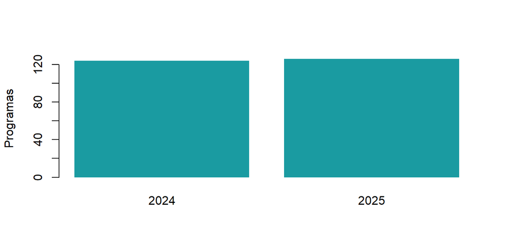

Programas por año.

```r
# Gráfica
barplot(resumen_anio$Programas, names.arg = resumen_anio$Año,
        col = "#1a9ba1", border = NA, ylab = "Programas")
```

Texto con valores calculados: el Excel tiene **250** programas de **19** dependencias.

## Parámetros y reutilización de documentos

Con `params` en el YAML, un mismo `.Rmd` genera varios informes. El proyecto incluye `demos/informe_parametrizado.Rmd` como **ejemplo completo**:

````
---
title: "Informe de avance de programas `r params$anio`"
lang: es
output:
  html_document:
    theme: flatly
    toc: true
    css: ../manual/estilos.css
params:
  anio: 2025
---

```{r setup, include = FALSE}
# El informe está en demos/; la raíz del proyecto está un nivel arriba.
knitr::opts_knit$set(root.dir = normalizePath(".."))
knitr::opts_chunk$set(echo = FALSE, message = FALSE, warning = FALSE,
                      fig.align = "center", fig.width = 7, fig.height = 4)
```

```{r datos}
source(file.path("scripts", "validar_datos.R"), encoding = "UTF-8")
source(file.path("dashboard", "graficas.R"), encoding = "UTF-8")

programas <- cargar_datos(file.path("datos", "datos.xlsx"))
if (!params$anio %in% programas$ANIO) {
  stop("El año ", params$anio, " no existe en los datos. Años disponibles: ",
       paste(sort(unique(programas$ANIO)), collapse = ", "))
}
d <- programas[programas$ANIO == params$anio, ]
k <- calcular_kpis(d)
```

## Resumen

En `r params$anio` se registraron **`r k$total_programas` programas** de
**`r length(unique(d$DEPENDENCIA))` dependencias**. De ellos, `r k$completos` tienen
avance global completo y `r k$con_avance` tienen avance parcial. El avance global
promedio es de **`r formato_pct(k$avance_global)`**.

```{r kpis}
knitr::kable(
  data.frame(
    Indicador = c("Total programas", "Programas completos", "Programas con avance",
                  "Total apoyos", "Avance programa", "Avance apoyos", "Avance global"),
    Valor = c(formato_entero(k$total_programas), formato_entero(k$completos),
              formato_entero(k$con_avance), formato_entero(k$total_apoyos),
              formato_pct(k$avance_programa), formato_pct(k$avance_apoyos),
              formato_pct(k$avance_global))
  ),
  align = "lr"
)
```

## Avance global por dependencia

```{r avance, fig.height = 5}
grafica_avance_dependencia(d)
```

## Responsables sin asignar

```{r responsables, fig.height = 3}
grafica_responsables(d)
```

## Programas sin titular RP

```{r tabla, results = "asis"}
sin_rp <- d[is.na(d$TITULAR_RP), c("CLAVE", "PROGRAMA", "DEPENDENCIA_CORTA")]
if (nrow(sin_rp) == 0) {
  cat("Todos los programas tienen titular RP asignado.")
} else {
  knitr::kable(sin_rp[order(sin_rp$DEPENDENCIA_CORTA), ],
               col.names = c("Clave", "Programa", "Dependencia"), row.names = FALSE)
}
```

---

*Fuente: datos/datos.xlsx. Informe generado el `r format(Sys.Date(), "%d/%m/%Y")` con el parámetro anio = `r params$anio`.*
````

Para generar un informe por año:

```r
for (anio in c(2024, 2025)) {
  rmarkdown::render(
    "demos/informe_parametrizado.Rmd",
    params = list(anio = anio),
    output_file = paste0("informe_", anio, ".html"),
    output_dir = "salidas"
  )
}
```

En RStudio también puedes usar *Knit → Knit with Parameters…*.

## Generación de informes HTML

| Forma | Comando |
| --- | --- |
| Botón **Knit** | `Ctrl + Shift + K` |
| Consola de R | `rmarkdown::render("demos/01_fundamentos.Rmd")` |
| PowerShell | `Rscript -e "rmarkdown::render('demos/01_fundamentos.Rmd')"` |
| Todo el proyecto | `Rscript scripts/generar_documentacion.R` |

El HTML resultante es **autónomo**: incluye imágenes y estilos, así que puedes enviarlo por correo o abrirlo sin R.

## Organización de documentos y recursos externos

- Guarda las imágenes en una carpeta `recursos/` junto al `.Rmd` y enlázalas con rutas relativas: `![Logo](recursos/logo.png)`.
- Usa `knitr::include_graphics("recursos/imagen.png")` para insertar imágenes desde un chunk.
- Divide documentos largos con **documentos hijo** (*child*). Este manual se construye así: `manual/index.Rmd` incluye cada archivo de `manual/modulos/`:

````markdown
```{r, child = "modulos/01_fundamentos.Rmd"}
```
````

- Los chunks se ejecutan en la carpeta del `.Rmd`. Este proyecto usa `knitr::opts_knit$set(root.dir = ...)` para que todos usen la carpeta raíz del proyecto.

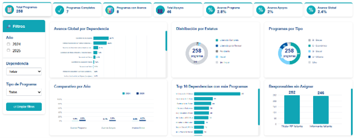

Imagen de referencia del dashboard.

```r
knitr::include_graphics(normalizePath(file.path("manual", "recursos", "dashboard.png")), rel_path = FALSE)
```

## Errores de renderizado y solución de problemas

| Error | Causa | Solución |
| --- | --- | --- |
| `object 'x' not found` al hacer Knit, aunque en la consola funciona | Knit usa una sesión **nueva**: no ve tu Environment | Crea o carga todo dentro del documento |
| `Duplicate chunk label 'x'` | Dos chunks con el mismo nombre | Cambia uno de los nombres |
| `pandoc version 1.12.3 or higher is required` | No se encuentra Pandoc | Usa Knit en RStudio o instala Pandoc |
| `Error in yaml::yaml.load` / `Scanner error` | Sangría o comillas incorrectas en el YAML | Revisa los espacios y los dos puntos |
| `cannot open file 'datos/...'` | Carpeta de trabajo distinta | Define `root.dir` o usa rutas desde la carpeta del `.Rmd` |
| `there is no package called 'X'` | Falta el paquete | `source("requirements.R")` |
| Los acentos se ven mal | El archivo no está en UTF-8 | *File → Save with Encoding → UTF-8* |

**Ejercicio:** crea un archivo `.Rmd` con un título, un chunk que calcule el promedio de `AVANCE_GLOBAL` y una frase con ese valor en línea. Genera el HTML con Knit.

**Ver solución**

````markdown
---
title: "Avance promedio"
output: html_document
---

```{r setup, include = FALSE}
knitr::opts_knit$set(root.dir = normalizePath(".."))
```

```{r}
source("scripts/validar_datos.R", encoding = "UTF-8")
programas <- cargar_datos()
promedio <- mean(programas$AVANCE_GLOBAL, na.rm = TRUE)
```

El avance global promedio es `r round(promedio * 100, 1)`%.
````

Guarda el archivo dentro de `demos/` para que `normalizePath("..")` apunte a la raíz del proyecto.

← Módulo 3 · Módulo 5 →

# Módulo 5. HTML, CSS y contenido dinámico

**Objetivo:** entender cómo se construye una página web, darle estilo con CSS y generar contenido HTML con R. Esto prepara el terreno para el dashboard.

## ¿Qué se ejecuta dónde?

| Pieza | ¿Quién la procesa? | ¿Cuándo? |
| --- | --- | --- |
| Código R en un `.Rmd` | **R**, en tu computadora | Al generar el documento (Knit) |
| HTML | **El navegador** | Al abrir el archivo |
| CSS | **El navegador** | Al abrir el archivo |
| JavaScript | **El navegador** | Al abrir y mientras usas la página |
| Código R en Shiny | **R** (servidor), de forma continua | Cada vez que cambias un control |

Un informe HTML de R Markdown es **estático**: R ya terminó de calcular y el navegador solo muestra el resultado. Un dashboard Shiny es **interactivo**: el navegador le pide a R que vuelva a calcular cada vez que cambias un filtro.

## Estructura básica de HTML

HTML describe el **contenido** de una página mediante **etiquetas** (`<etiqueta>contenido</etiqueta>`).

```html
<!DOCTYPE html>
<html lang="es">
<head>
  <meta charset="utf-8">
  <meta name="viewport" content="width=device-width, initial-scale=1">
  <title>Mi página</title>
  <link rel="stylesheet" href="estilos.css">
</head>
<body>
  <h1>Avance de programas</h1>
  <p>Hay <strong>250</strong> programas registrados.</p>
  <div class="kpi" id="kpi-total">
    <span class="kpi-titulo">Total programas</span>
    <span class="kpi-valor">250</span>
  </div>
  <img src="recursos/dashboard.png" alt="Dashboard de referencia">
  <a href="https://cran.r-project.org">CRAN</a>
</body>
</html>
```

| Etiqueta | Uso |
| --- | --- |
| `<h1>`…`<h6>` | Títulos |
| `<p>` | Párrafo |
| `<div>` / `<span>` | Contenedor de bloque / en línea (sirven para aplicar estilos) |
| `<table>`, `<tr>`, `<td>` | Tablas |
| `<img>`, `<a>` | Imagen y enlace |
| `class="..."`, `id="..."` | Atributos para identificar elementos desde CSS o JavaScript |

**Ejercicio:** escribe el HTML de una tarjeta con el título “Avance global” y el valor “97.2%”.

**Ver solución**

```html
<div class="kpi">
  <span class="kpi-titulo">Avance global</span>
  <span class="kpi-valor">97.2%</span>
</div>
```

**Errores comunes:** no cerrar etiquetas (`<div>` sin `</div>`), lo que desacomoda toda la página, y olvidar `<meta charset="utf-8">`, lo que hace que los acentos se vean mal.

## Selectores, propiedades y reglas CSS

CSS define la **apariencia**. Una regla tiene un **selector** (a qué elementos se aplica) y **propiedades** (qué cambia).

```css
/* selector { propiedad: valor; } */
h1 { color: #0e6e73; }          /* etiqueta */
.kpi {                            /* clase: empieza con punto */
  background: white;
  border-radius: 10px;
  padding: 12px;
  box-shadow: 0 2px 6px rgba(0, 0, 0, 0.08);
}
#kpi-total { border-top: 4px solid #1a9ba1; }  /* id: empieza con # */
.kpi .kpi-valor { font-size: 1.4rem; font-weight: bold; }  /* descendiente */
```

| Propiedad | Ejemplo | Efecto |
| --- | --- | --- |
| `color`, `background` | `color: #2c3e50;` | Color del texto y del fondo |
| `font-size`, `font-weight` | `font-size: 1.2rem;` | Tamaño y grosor de la letra |
| `margin`, `padding` | `padding: 12px;` | Espacio exterior e interior |
| `border`, `border-radius` | `border-radius: 10px;` | Borde y esquinas redondeadas |
| `display: grid` / `flex` | `display: grid;` | Acomodar elementos en filas y columnas |

**Ejercicio:** escribe una regla para que todos los elementos con clase `alerta` tengan el texto rojo y la letra en negrita.

**Ver solución**

```css
.alerta { color: #c0392b; font-weight: bold; }
```

**Errores comunes:** olvidar el `;` al final de cada propiedad (la regla se ignora a partir de ese punto) y escribir `kpi` en lugar de `.kpi` para seleccionar una clase.

## Diseño adaptable a distintos tamaños de pantalla

Con **CSS Grid** y **media queries**, la misma página se reacomoda según el ancho de la pantalla:

```css
.fila-kpi {
  display: grid;
  grid-template-columns: repeat(4, 1fr);   /* 4 columnas iguales */
  gap: 12px;
}
@media (max-width: 992px) {                /* tabletas */
  .fila-kpi { grid-template-columns: repeat(2, 1fr); }
}
@media (max-width: 600px) {                /* teléfonos */
  .fila-kpi { grid-template-columns: 1fr; }
}
```

Para que funcione en teléfonos, el HTML necesita `<meta name="viewport" content="width=device-width, initial-scale=1">`. R Markdown y Shiny ya la incluyen.

El archivo `dashboard/estilos.css` usa exactamente esta técnica. Para probarla, abre el dashboard y reduce el ancho de la ventana, o presiona `F12` en el navegador y activa el modo de dispositivo.

## Integración de HTML y CSS en R Markdown

Tres formas de agregar estilos a un `.Rmd`:

1. Un archivo externo en el YAML: `output: html_document: css: estilos.css` (es lo que usa este manual).
2. Un chunk de tipo `css`:

```css
.tarjeta-demo {
  display: inline-block;
  background: #fff;
  border-top: 4px solid #1a9ba1;
  border-radius: 10px;
  box-shadow: 0 2px 6px rgba(0, 0, 0, 0.1);
  padding: 10px 18px;
  margin: 6px 10px 6px 0;
  min-width: 150px;
}
.tarjeta-demo .titulo { font-size: 0.8rem; color: #6c7a86; }
.tarjeta-demo .valor { font-size: 1.5rem; font-weight: 700; color: #2c3e50; }
```

3. HTML escrito directamente en el texto de Markdown: este texto usa estilo en línea.

## Contenido dinámico generado con R

R puede **escribir HTML**. Con `results = "asis"`, el texto que imprime el chunk se inserta tal cual en la página.

```r
if (!exists("programas")) {
  source(file.path("scripts", "validar_datos.R"), encoding = "UTF-8")
  programas <- cargar_datos()
}

tarjeta <- function(titulo, valor) {
  sprintf('<div class="tarjeta-demo"><div class="titulo">%s</div><div class="valor">%s</div></div>',
          titulo, valor)
}

cat(
  tarjeta("Total programas", nrow(programas)),
  tarjeta("Completos", sum(programas$COMPLETO)),
  tarjeta("Avance global", paste0(round(mean(programas$AVANCE_GLOBAL, na.rm = TRUE) * 100, 1), "%")),
  sep = "\n"
)
```

Total programas

250

Completos

170

Avance global

97.2%

**Resultado:** las tres tarjetas se calculan con los datos del Excel. Si los datos cambian, basta con volver a generar el documento.

El paquete `htmltools` (se instala junto con `shiny` y `rmarkdown`) construye HTML con funciones en lugar de texto. Es la forma que usa Shiny:

```r
library(htmltools)
tags$div(
  class = "tarjeta-demo",
  tags$div(class = "titulo", "Dependencias"),
  tags$div(class = "valor", length(unique(programas$DEPENDENCIA)))
)
```

Dependencias

19

## Parámetros, tablas filtradas, indicadores y visualizaciones

Combinando parámetros (módulo 4) con HTML generado por R obtienes informes que cambian según un valor. Aquí, un año fijado en una variable:

```r
anio_elegido <- 2025
d <- programas[programas$ANIO == anio_elegido, ]

cat(tarjeta(paste("Programas", anio_elegido), nrow(d)),
    tarjeta("Sin titular RP", sum(is.na(d$TITULAR_RP))), sep = "\n")
```

Programas 2025

126

Sin titular RP

39

```r
top <- sort(table(d$DEPENDENCIA_CORTA), decreasing = TRUE)[1:5]
print(knitr::kable(data.frame(Dependencia = names(top), Programas = as.integer(top)),
                   format = "html", table.attr = 'class="table table-striped"'))
```

| Dependencia | Programas |
| --- | --- |
| Secretaría de Educación Pública | 31 |
| Secretaría de Cultura | 12 |
| Secretaría de Salud | 11 |
| ISSSTE | 10 |
| Secretaría de Agricultura y Des… | 10 |

**Ejercicio:** cambia `anio_elegido` a 2024 y genera de nuevo el documento. ¿Qué tarjetas cambian?

**Ver solución**

Cambian todas, porque se calculan con `d`, que depende de `anio_elegido`. Así se ve con 2024:

```r
d <- programas[programas$ANIO == 2024, ]
c(programas = nrow(d), sin_titular = sum(is.na(d$TITULAR_RP)))
```

```
##   programas sin_titular
##         124          40
```

## Introducción a JavaScript (solo cuando es necesario)

JavaScript se ejecuta **en el navegador** y permite reaccionar a clics y escritura **sin volver a R**. Este manual lo usa para el buscador del menú lateral. Ejemplo mínimo:

```html
<button onclick="
  var p = document.getElementById('m5-mensaje');
  p.textContent = 'Clic recibido a las ' + new Date().toLocaleTimeString();
">Presióname</button>
<span id="m5-mensaje"></span>
```

JavaScript **no puede** volver a ejecutar R. Por eso no basta para recalcular promedios con datos filtrados de forma general; para eso se usa Shiny (módulo 7).

## Informe HTML estático frente a dashboard interactivo

|  | Informe R Markdown (HTML) | Dashboard Shiny |
| --- | --- | --- |
| ¿Necesita R abierto? | No: es un archivo | Sí: R funciona como servidor |
| ¿Se puede enviar por correo? | Sí | No (se comparte la carpeta o se publica en un servidor) |
| Filtros que recalculan | No (salvo JavaScript limitado) | Sí, todos |
| Cuándo usarlo | Reportes periódicos, documentación | Exploración de datos, monitoreo |
| En este proyecto | `manual/index.html`, `salidas/*.html` | `dashboard/app.R` |

**Error común:** llamar “dashboard interactivo” a un HTML que solo tiene gráficas fijas. Si los filtros no cambian los números, no es interactivo.

← Módulo 4 · Módulo 6 →

# Módulo 6. Análisis y visualización de datos

**Objetivo:** explorar los datos del Excel, calcular estadísticas e indicadores, y elegir y construir la gráfica adecuada para cada pregunta.

## Importación del Excel

Usamos la función del proyecto, que ya limpia y valida los datos (módulo 2):

```r
source(file.path("scripts", "validar_datos.R"), encoding = "UTF-8")
programas <- cargar_datos(file.path("datos", "datos.xlsx"))
dim(programas)
```

```
## [1] 250  22
```

## Exploración y descripción de los datos

```r
str(programas[, c("TIPO", "ESTATUS", "ANIO", "AVANCE_PROGRAMA", "AVANCE_APOYOS",
                  "TOTAL_APOYOS", "AVANCE_GLOBAL", "ULTIMA_MODIFICACION")])
```

```
## 'data.frame':    250 obs. of  8 variables:
##  $ TIPO               : chr  "U" "S" "U" "U" ...
##  $ ESTATUS            : int  3 1 1 2 1 1 1 1 1 2 ...
##  $ ANIO               : int  2025 2024 2025 2025 2025 2024 2024 2024 2024 2024 ...
##  $ AVANCE_PROGRAMA    : num  1 1 0 1 1 1 1 1 1 1 ...
##  $ AVANCE_APOYOS      : num  1 0.833 NA 1 1 ...
##  $ TOTAL_APOYOS       : num  1 2 NA 1 1 1 3 4 3 1 ...
##  $ AVANCE_GLOBAL      : num  1 0.917 NA 1 1 ...
##  $ ULTIMA_MODIFICACION: Date, format: "2026-11-09" "2026-11-05" ...
```

```r
head(programas[, c("CLAVE", "DEPENDENCIA_CORTA", "ANIO", "AVANCE_GLOBAL")], 5)
```

```
##    CLAVE         DEPENDENCIA_CORTA ANIO AVANCE_GLOBAL
## 1 54U001 Secretaría de las Mujeres 2025       1.00000
## 2 47S313            IMSS-BIENESTAR 2024       0.91665
## 3 47U313            IMSS-BIENESTAR 2025            NA
## 4 51U001                    ISSSTE 2025       1.00000
## 5 38E004                   Secihti 2025       1.00000
```

```r
table(programas$TIPO)
```

```
##
##   B   E   S   U
##   6 123  88  33
```

```r
table(programas$ESTATUS_ETIQUETA, programas$ANIO)   # tabla cruzada
```

```
##
##                         2024 2025
##   Sin ingreso o captura    0    5
##   Pendiente              105  103
##   Liberado Informante      2    3
##   Liberado Titular RP     17   15
##   Liberado Titular AE      0    0
##   Sin estatus              0    0
##   Estatus 0                0    0
##   Estatus 1                0    0
##   Estatus 2                0    0
##   Estatus 3                0    0
```

```r
length(unique(programas$DEPENDENCIA))
```

```
## [1] 19
```

**Resultado:** hay programas de dos años y cuatro tipos. La tabla cruzada muestra cuántos hay de cada estatus en cada año.

## Estadística descriptiva

| Medida | Función | Qué indica |
| --- | --- | --- |
| Media | `mean()` | Valor promedio (sensible a valores extremos) |
| Mediana | `median()` | Valor central |
| Mínimo, máximo | `min()`, `max()`, `range()` | Extremos |
| Desviación estándar | `sd()` | Qué tan dispersos están los valores |
| Cuartiles | `quantile()` | Valores que dividen los datos en cuatro partes |
| Resumen | `summary()` | Todo lo anterior junto |

```r
summary(programas$TOTAL_APOYOS)
```

```
##    Min. 1st Qu.  Median    Mean 3rd Qu.    Max.     NAs
##   1.000   1.000   2.000   3.333   4.000  25.000      19
```

```r
sd(programas$TOTAL_APOYOS, na.rm = TRUE)
```

```
## [1] 3.736619
```

```r
quantile(programas$TOTAL_APOYOS, c(0.25, 0.5, 0.75, 0.9), na.rm = TRUE)
```

```
## 25% 50% 75% 90%
##   1   2   4   8
```

**Resultado:** la media del total de apoyos es mayor que la mediana porque unos pocos programas tienen muchos apoyos (el máximo es 25). Cuando hay valores extremos, la mediana describe mejor el caso típico.

**Ejercicio:** calcula la media y la mediana de `AVANCE_GLOBAL`. ¿Cuál es mayor y por qué?

**Ver solución**

```r
mean(programas$AVANCE_GLOBAL, na.rm = TRUE)
```

```
## [1] 0.9720645
```

```r
median(programas$AVANCE_GLOBAL, na.rm = TRUE)
```

```
## [1] 1
```

La mediana es 1 porque más de la mitad de los programas están completos. La media es menor porque los programas con poco avance la bajan.

**Error común:** olvidar `na.rm = TRUE`: el resultado es `NA`.

## Agrupaciones, resúmenes y filtros

`aggregate()` calcula una estadística **por grupo**. La fórmula `variable ~ grupo` se lee como “variable según grupo”.

```r
# Avance global promedio por año
aggregate(AVANCE_GLOBAL ~ ANIO, data = programas, FUN = mean)
```

```
##   ANIO AVANCE_GLOBAL
## 1 2024     0.9715927
## 2 2025     0.9725487
```

```r
# Número de programas por dependencia, ordenado
por_dep <- aggregate(CLAVE ~ DEPENDENCIA_CORTA, data = programas, FUN = length)
names(por_dep)[2] <- "programas"
head(por_dep[order(-por_dep$programas), ], 5)
```

```
##                     DEPENDENCIA_CORTA programas
## 14    Secretaría de Educación Pública        62
## 11              Secretaría de Cultura        25
## 18                Secretaría de Salud        23
## 9  Secretaría de Agricultura y Des...        20
## 17 Secretaría de Medio Ambiente y ...        20
```

```r
# Varias estadísticas a la vez
aggregate(TOTAL_APOYOS ~ TIPO, data = programas,
          FUN = function(x) c(total = sum(x), promedio = round(mean(x), 2)))
```

```
##   TIPO TOTAL_APOYOS.total TOTAL_APOYOS.promedio
## 1    B              10.00                  1.67
## 2    E             358.00                  3.01
## 3    S             280.00                  3.59
## 4    U             122.00                  4.36
```

```r
# Filtrar y resumir: programas de 2025 sin titular RP, por dependencia
sin_rp <- programas[programas$ANIO == 2025 & is.na(programas$TITULAR_RP), ]
sort(table(sin_rp$DEPENDENCIA_CORTA), decreasing = TRUE)[1:5]
```

```
##
## Secretaría de Educación Pública                         Secihti
##                              31                               4
##                  IMSS-BIENESTAR                            INPI
##                               2                               2
##                            <NA>
##
```

**Ejercicio:** calcula el total de apoyos por año.

**Ver solución**

```r
aggregate(TOTAL_APOYOS ~ ANIO, data = programas, FUN = sum)
```

```
##   ANIO TOTAL_APOYOS
## 1 2024          389
## 2 2025          381
```

**Error común:** con fórmula, `aggregate()` **elimina las filas con `NA`** en las variables usadas. Es lo que queremos para promediar, pero al contar filas puede dar un número menor del esperado.

## Indicadores estadísticos

Los indicadores (KPI) resumen la situación en un número. Estos son los del dashboard, con su definición:

```r
source(file.path("dashboard", "graficas.R"), encoding = "UTF-8")
kpis <- calcular_kpis(programas)
data.frame(
  indicador = c("Total programas", "Programas completos", "Programas con avance",
                "Total apoyos", "Avance programa", "Avance apoyos", "Avance global"),
  definicion = c("Número de filas", "Avance global = 100 %", "Avance global entre 0 % y 100 %",
                 "Suma de TOTAL_APOYOS", "Promedio de AVANCE_PROGRAMA",
                 "Promedio de AVANCE_APOYOS", "Promedio de AVANCE_GLOBAL"),
  valor = c(kpis$total_programas, kpis$completos, kpis$con_avance, kpis$total_apoyos,
            formato_pct(kpis$avance_programa), formato_pct(kpis$avance_apoyos),
            formato_pct(kpis$avance_global))
)
```

```
##              indicador                      definicion valor
## 1      Total programas                 Número de filas   250
## 2  Programas completos           Avance global = 100 %   170
## 3 Programas con avance Avance global entre 0 % y 100 %    61
## 4         Total apoyos            Suma de TOTAL_APOYOS   770
## 5      Avance programa     Promedio de AVANCE_PROGRAMA 93.5%
## 6        Avance apoyos       Promedio de AVANCE_APOYOS   95%
## 7        Avance global       Promedio de AVANCE_GLOBAL 97.2%
```

**Detalle importante:** el avance global promedio es **mayor** que los otros dos promedios. La razón: los 19 programas sin avance de apoyos no tienen avance global, así que quedan fuera de ese promedio, y varios de ellos tienen avance de programa bajo.

```r
sin_global <- programas[is.na(programas$AVANCE_GLOBAL), ]
nrow(sin_global)
```

```
## [1] 19
```

```r
mean(sin_global$AVANCE_PROGRAMA)
```

```
## [1] 0.2210526
```

Siempre documenta **cómo** se calcula cada indicador y **qué datos excluye**.

## Selección apropiada de gráficas

| Pregunta | Tipo de gráfica | Por qué |
| --- | --- | --- |
| ¿Cómo se compara una cantidad entre categorías? | Barras (horizontales si los nombres son largos) | Comparar longitudes es fácil y preciso |
| ¿Qué proporción representa cada parte del total? | Dona o pastel (pocas categorías) | Muestra la relación parte–todo |
| ¿Cómo cambia algo en el tiempo? | Líneas | Muestra la tendencia |
| ¿Cómo se distribuye una variable? | Histograma o diagrama de caja | Muestra la forma, el centro y los extremos |
| ¿Se relacionan dos variables numéricas? | Dispersión | Cada punto es una observación |

## Gráficas con ggplot2

`ggplot2` construye gráficas por **capas**: datos + estética (`aes`: qué variable va en cada eje o color) + geometría (`geom_*`) + ajustes.

```r
ggplot(datos, aes(x = variable_x, y = variable_y)) +
  geom_col() +                 # tipo de gráfica
  labs(title = "...", x = "...", y = "...") +
  theme_minimal()
```

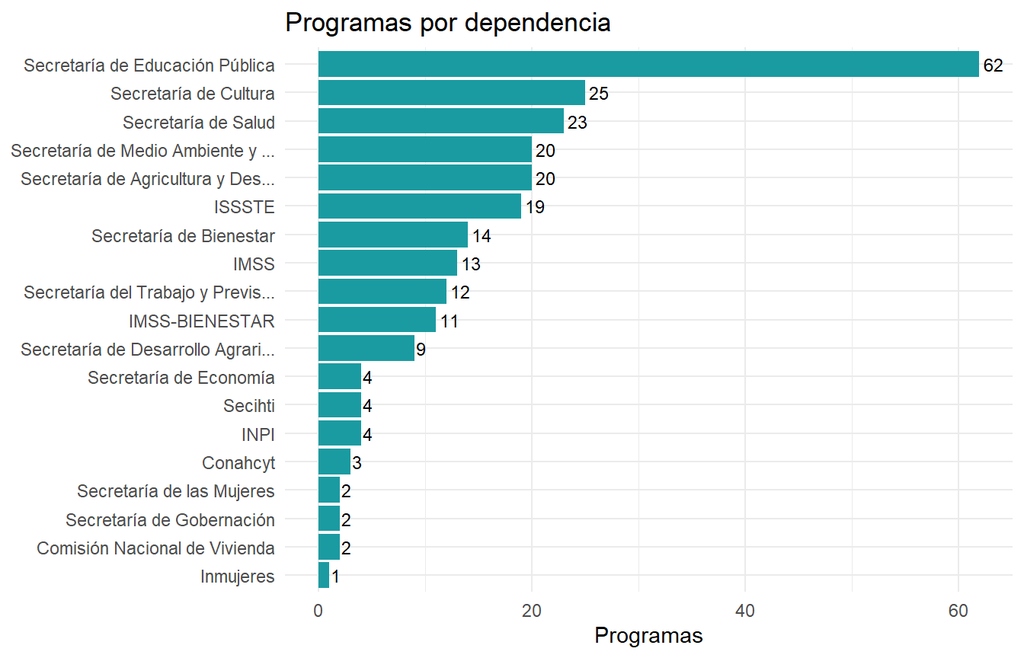

```r
library(ggplot2)

# Pregunta: ¿qué dependencias tienen más programas?
por_dep$DEPENDENCIA_CORTA <- reorder(por_dep$DEPENDENCIA_CORTA, por_dep$programas)
ggplot(por_dep, aes(x = programas, y = DEPENDENCIA_CORTA)) +
  geom_col(fill = "#1a9ba1") +
  geom_text(aes(label = programas), hjust = -0.2, size = 3.2) +
  labs(title = "Programas por dependencia", x = "Programas", y = NULL) +
  theme_minimal()
```

**Lectura:** la Secretaría de Educación Pública concentra la mayor cantidad de programas, muy por encima de las demás.

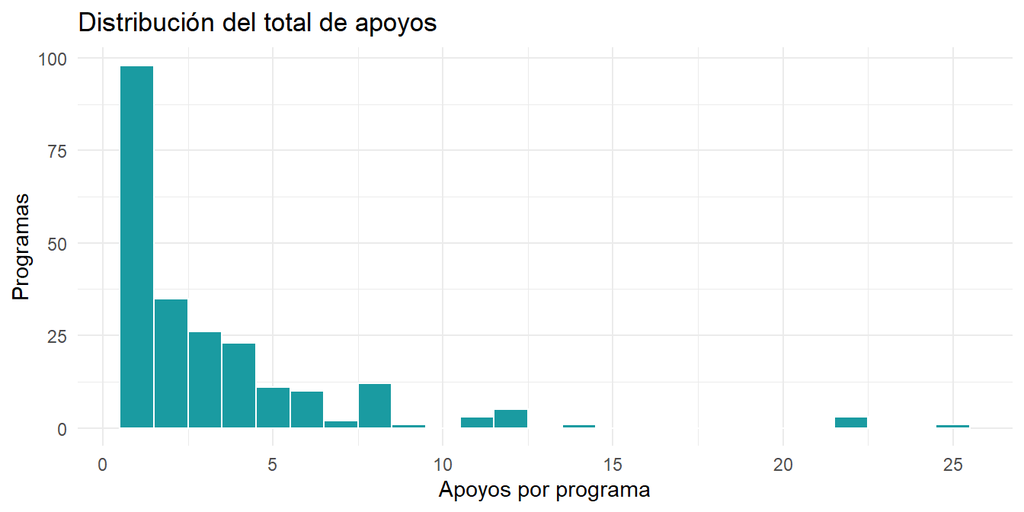

```r
# Pregunta: ¿cómo se distribuye el número de apoyos por programa?
ggplot(programas[!is.na(programas$TOTAL_APOYOS), ], aes(x = TOTAL_APOYOS)) +
  geom_histogram(binwidth = 1, fill = "#1a9ba1", color = "white") +
  labs(title = "Distribución del total de apoyos", x = "Apoyos por programa", y = "Programas") +
  theme_minimal()
```

**Lectura:** la mayoría de los programas tiene entre 1 y 4 apoyos; unos pocos tienen muchos más.

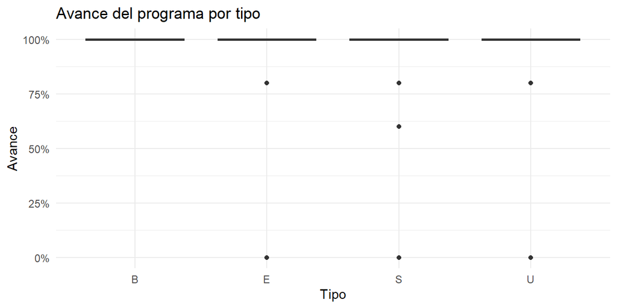

```r
# Pregunta: ¿el avance del programa es distinto según el tipo?
ggplot(programas, aes(x = TIPO, y = AVANCE_PROGRAMA, fill = TIPO)) +
  geom_boxplot(show.legend = FALSE) +
  scale_y_continuous(labels = function(x) paste0(x * 100, "%")) +
  labs(title = "Avance del programa por tipo", x = "Tipo", y = "Avance") +
  theme_minimal()
```

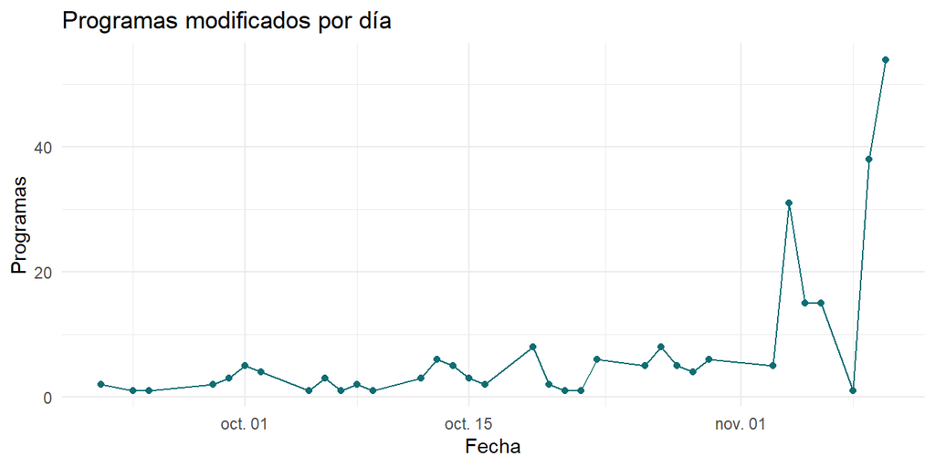

```r
# Pregunta: ¿cuántos programas se modificaron cada día?
por_dia <- aggregate(CLAVE ~ ULTIMA_MODIFICACION, data = programas, FUN = length)
ggplot(por_dia, aes(x = ULTIMA_MODIFICACION, y = CLAVE)) +
  geom_line(color = "#0e6e73") +
  geom_point(color = "#0e6e73") +
  labs(title = "Programas modificados por día", x = "Fecha", y = "Programas") +
  theme_minimal()
```

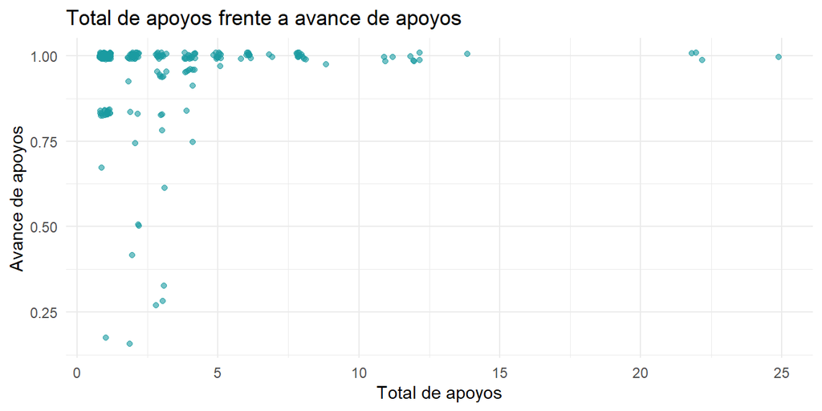

```r
# Pregunta: ¿los programas con más apoyos tienen menos avance de apoyos?
ggplot(programas, aes(x = TOTAL_APOYOS, y = AVANCE_APOYOS)) +
  geom_jitter(width = 0.2, height = 0.01, alpha = 0.6, color = "#1a9ba1", na.rm = TRUE) +
  labs(title = "Total de apoyos frente a avance de apoyos", x = "Total de apoyos",
       y = "Avance de apoyos") +
  theme_minimal()
```

Guardar una gráfica en un archivo:

```r
ggsave(file.path("salidas", "programas_por_dependencia.png"), width = 8, height = 5, dpi = 150)
```

**Ejercicio:** haz una gráfica de barras agrupadas con el número de programas por tipo y año (`fill = factor(ANIO)`, `position = "dodge"`).

**Ver solución**

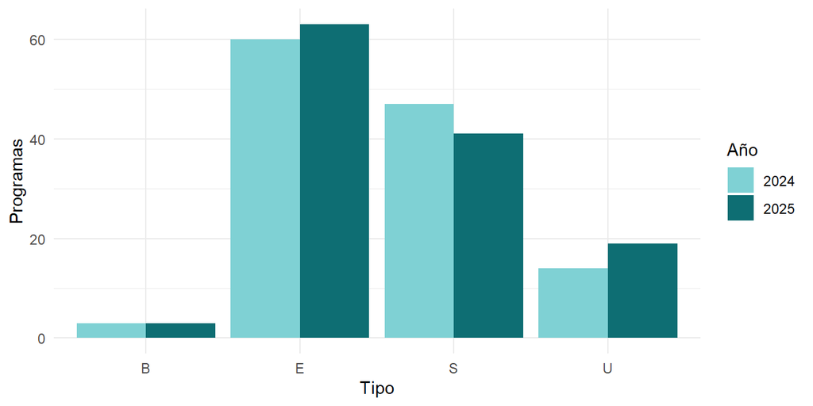

```r
ggplot(programas, aes(x = TIPO, fill = factor(ANIO))) +
  geom_bar(position = "dodge") +
  scale_fill_manual(values = c("#7fd1d4", "#0e6e73"), name = "Año") +
  labs(x = "Tipo", y = "Programas") +
  theme_minimal()
```

**Errores comunes**

| Error | Causa |
| --- | --- |
| `could not find function "ggplot"` | Falta `library(ggplot2)` |
| `object 'X' not found` dentro de `aes()` | La columna no existe en el data frame |
| Un `+` al inicio de la línea siguiente | El `+` debe ir **al final** de la línea anterior |
| `geom_bar()` con una columna `y` | Usa `geom_col()` cuando ya tienes los valores; `geom_bar()` cuenta filas |
| Las barras salen en orden alfabético | Usa `reorder()` para ordenarlas por valor |

## Tablas de resultados

```r
tabla <- aggregate(cbind(AVANCE_PROGRAMA, AVANCE_APOYOS, AVANCE_GLOBAL) ~ TIPO_ETIQUETA,
                   data = programas, FUN = mean)
tabla[, -1] <- lapply(tabla[, -1], function(x) paste0(round(x * 100, 1), "%"))
knitr::kable(tabla, col.names = c("Tipo", "Avance programa", "Avance apoyos", "Avance global"),
             align = "lrrr", caption = "Avance promedio por tipo de programa")
```

Avance promedio por tipo de programa

| Tipo | Avance programa | Avance apoyos | Avance global |
| --- | --- | --- | --- |
| B - Provisión de bienes públicos | 100% | 100% | 100% |
| E - Prestación de servicios públicos | 99.5% | 96.4% | 98% |
| S - Sujetos a reglas de operación | 99.5% | 93.1% | 96.3% |
| U - Otros subsidios | 98.6% | 93.3% | 95.9% |

`cbind()` dentro de la fórmula resume varias columnas a la vez. Esta forma solo usa las filas que tienen **los tres** avances.

## Validación de resultados y consistencia de los datos

Antes de publicar un número, compruébalo por otro camino:

```r
# 1. La suma por grupos debe ser igual al total
sum(table(programas$TIPO)) == nrow(programas)
```

```
## [1] TRUE
```

```r
# 2. Completos + con avance + sin avance + sin dato = total
sin_avance <- sum(!is.na(programas$AVANCE_GLOBAL) & programas$AVANCE_GLOBAL == 0)
sin_dato <- sum(is.na(programas$AVANCE_GLOBAL))
sum(programas$COMPLETO) + sum(programas$CON_AVANCE) + sin_avance + sin_dato == nrow(programas)
```

```
## [1] TRUE
```

```r
# 3. La regla de la hoja SQL se cumple
knitr::kable(validar_datos(programas))
```

| revision | resultado | detalle |
| --- | --- | --- |
| Filas leídas | OK | 250 programas |
| Años | OK | 2024, 2025 |
| Códigos de estatus conocidos | OK | 0, 1, 2, 3 |
| Tipo = 3er carácter de la clave | OK | 0 diferencias |
| Avances entre 0 y 1 | OK | AVANCE_PROGRAMA, AVANCE_APOYOS, AVANCE_GLOBAL |
| Avance global = promedio de avances | OK | Regla tomada de la hoja SQL |
| Avance global sin dato | OK | 19 programas (se excluyen de los promedios) |
| Titular RP sin asignar | OK | 79 programas |
| Informante sin asignar | OK | 2 programas |
| Fechas de modificación válidas | OK | 0 sin fecha |
| Clave + año sin duplicar | OK | 0 posibles duplicados |

**Ejercicio:** verifica que la suma de los programas por año sea igual al total de filas.

**Ver solución**

```r
sum(table(programas$ANIO)) == nrow(programas)
```

```
## [1] TRUE
```

← Módulo 5 · Módulo 7 →

# Módulo 7. Dashboard dinámico

**Objetivo:** construir un dashboard interactivo que reproduzca el diseño de referencia con los datos reales y que recalcule indicadores, gráficas y tablas cuando cambian los filtros.

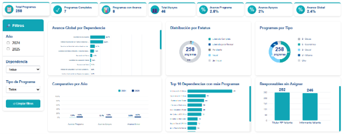

Diseño de referencia (dashboard.png). Sus cifras provienen de otra extracción; el dashboard calcula las suyas a partir de datos.xlsx.

## Elección de la tecnología

| Opción | ¿Filtros que recalculan? | ¿Necesita servidor R? | Decisión |
| --- | --- | --- | --- |
| R Markdown con gráficas estáticas | No | No | Descartada: no es interactivo |
| `flexdashboard` sin Shiny | Solo con widgets de JavaScript; no recalcula promedios | No | Descartada: los KPI no se actualizarían |
| `flexdashboard` + Shiny | Sí | Sí | Válida |
| **Shiny + bslib** | **Sí** | **Sí** | **Elegida**: control total del diseño con CSS Grid, menos dependencias y el mismo código sirve en RStudio y en PowerShell |

**Consecuencia:** el dashboard interactivo se usa con R abierto como servidor local. No es un archivo HTML que se pueda enviar por correo.

**Versión HTML para compartir:** además se genera `salidas/dashboard.html` desde `dashboard/dashboard_estatico.Rmd`. Reutiliza las mismas funciones de `graficas.R` y el mismo `estilos.css`, pero R calcula todo **una sola vez**, al generar el archivo:

|  | `dashboard/app.R` (Shiny) | `salidas/dashboard.html` |
| --- | --- | --- |
| Se abre con | `shiny::runApp("dashboard")` | Doble clic (cualquier navegador) |
| Necesita R | Sí, mientras se usa | Solo para generarlo |
| Filtros | Año, dependencia y tipo; recalculan todo | No hay filtros: pestañas fijas “Todos los años” y una por año |
| Gráficas | Se redibujan en cada cambio | Imágenes PNG incrustadas en el HTML |
| Se puede enviar por correo | No | Sí (un solo archivo, ~1 MB) |

```powershell
# PowerShell, en la carpeta proyecto_r: genera solo el HTML
Rscript scripts/generar_dashboard.R --solo-html
```

Lo único que hace el navegador en el HTML es cambiar de pestaña (JavaScript de Bootstrap incluido por R Markdown). Para compartir un informe por año con texto explicativo, usa el informe con parámetros del módulo 4.

## Arquitectura

```
datos/datos.xlsx
      │  cargar_datos()            scripts/validar_datos.R   (lectura, limpieza, validación)
      ▼
  programas (data frame limpio)
      │  filtros (año, dependencia, tipo)
      ▼
  datos_filtrados()  ── reactive ──┐                         dashboard/app.R   (UI + servidor)
      │                            │
      ▼                            ▼
  calcular_kpis()            grafica_*()                     dashboard/graficas.R (cálculos y gráficas)
      │                            │
      └──────────► navegador ◄─────┘                         dashboard/estilos.css (apariencia)
```

Separar los archivos permite probar los cálculos sin abrir el dashboard. Las funciones de `graficas.R` funcionan en cualquier script o `.Rmd`, como se muestra al final de este módulo.

## Conceptos de Shiny

| Concepto | Qué es | En `app.R` |
| --- | --- | --- |
| **UI** | Qué se ve: controles, tarjetas y espacios para las gráficas | `ui <- page_fluid(...)` |
| **Server** | La función que calcula las salidas | `server <- function(input, output, session)` |
| **Input** | Valor de un control, que se lee en el servidor | `input$anio`, `input$dependencia` |
| **Output** | Resultado que se dibuja en la UI | `output$g_estatus <- renderPlot(...)` |
| **reactive()** | Cálculo que se repite solo cuando cambian sus inputs | `datos_filtrados <- reactive(...)` |
| **observeEvent()** | Acción ante un evento (por ejemplo, un clic) | Botón “Limpiar filtros” |
| **validate(need())** | Mensaje claro en lugar de un error | “No hay programas que cumplan los filtros” |

El flujo: cambias un filtro → el navegador envía el nuevo `input` a R → `datos_filtrados()` se recalcula → todas las salidas que dependen de él se vuelven a dibujar.

## Correspondencia con la imagen de referencia

| Elemento de la referencia | Implementación | Pregunta que responde |
| --- | --- | --- |
| 7 tarjetas KPI con icono | `tarjeta_kpi()` + `calcular_kpis()` | ¿Cuál es la situación general? |
| Panel de filtros: año, dependencia, tipo y “Limpiar filtros” | `checkboxGroupInput`, `selectInput`, `actionButton` | ¿Qué subconjunto quiero analizar? |
| Avance global por dependencia | `grafica_avance_dependencia()` | ¿Qué dependencias van más adelantadas o rezagadas? |
| Distribución por estatus (dona) | `grafica_estatus()` | ¿En qué estatus están los programas? |
| Programas por tipo (dona) | `grafica_tipo()` | ¿Qué tipos predominan? |
| Comparativo por año | `grafica_comparativo_anio()` | ¿Mejoró el avance de 2024 a 2025? |
| Top 10 dependencias | `grafica_top_dependencias()` | ¿Quién concentra más programas? |
| Responsables sin asignar | `grafica_responsables()` | ¿Cuántos programas no tienen responsable? |
| *(Agregado)* Tabla de detalle | `tableOutput("tabla")` | ¿Qué programas concretos hay detrás de los números? |

**Diferencias y limitaciones conocidas**

- **Cifras:** la imagen muestra otra extracción (258 programas). El dashboard usa siempre `datos.xlsx`.
- **Etiquetas de estatus y tipo:** se definen en un solo lugar, `ETIQUETAS_ESTATUS` y `ETIQUETAS_TIPO` en `scripts/validar_datos.R`. El Excel trae los estatus 0 a 3; el 4 (“Liberado Titular AE”) aparecerá si llega en datos futuros.
- **Definiciones de KPI:** los avances son proporciones (1 = 100 %). “Completo” significa avance global de 100 %; “con avance”, mayor que 0 % y menor que 100 %.
- **Nombres de dependencias:** en las gráficas se usa la sigla entre paréntesis o se recortan a 34 caracteres para que quepan.

## Diseño adaptable y estados vacíos

`dashboard/estilos.css` usa CSS Grid con tres puntos de corte:

| Ancho de pantalla | KPI por fila | Gráficas por fila | Filtros |
| --- | --- | --- | --- |
| Más de 1400 px | 7 | 3 | A la izquierda, fijos al desplazarse |
| 993–1400 px | 4 | 2 | A la izquierda |
| 601–992 px | 2 | 2 | Arriba |
| 600 px o menos | 1 | 1 | Arriba |

Si un filtro deja 0 programas (por ejemplo, si desmarcas los dos años), cada tarjeta muestra “No hay programas que cumplan los filtros seleccionados.” en lugar de un error. Los KPI de porcentaje muestran “Sin dato”.

## Cómo ejecutarlo

```r
# En RStudio, con proyecto_r.Rproj abierto:
shiny::runApp("dashboard")
```

```powershell
# En PowerShell, dentro de la carpeta proyecto_r:
Rscript scripts/generar_dashboard.R
# Abre http://127.0.0.1:3838 en el navegador. Ctrl + C para detenerlo.
```

En RStudio también puedes abrir `dashboard/app.R` y presionar el botón **Run App**.

## Las mismas funciones fuera de Shiny

Como los cálculos están separados de la interfaz, aquí se generan las gráficas del dashboard **sin filtros**. Esta versión es estática.

```r
if (!exists("programas")) {
  source(file.path("scripts", "validar_datos.R"), encoding = "UTF-8")
  programas <- cargar_datos()
}
source(file.path("dashboard", "graficas.R"), encoding = "UTF-8")
str(calcular_kpis(programas))
```

```
## List of 7
##  $ total_programas: int 250
##  $ completos      : int 170
##  $ con_avance     : int 61
##  $ total_apoyos   : num 770
##  $ avance_programa: num 0.935
##  $ avance_apoyos  : num 0.95
##  $ avance_global  : num 0.972
```

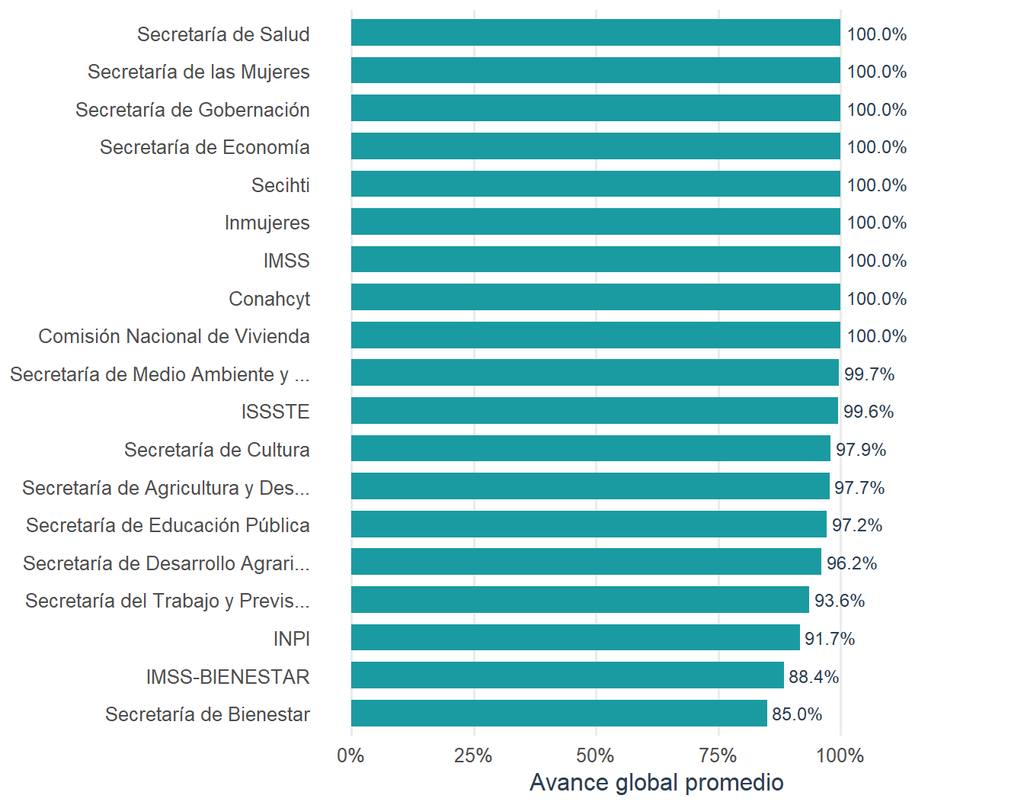

Avance global por dependencia.

```r
grafica_avance_dependencia(programas)
```

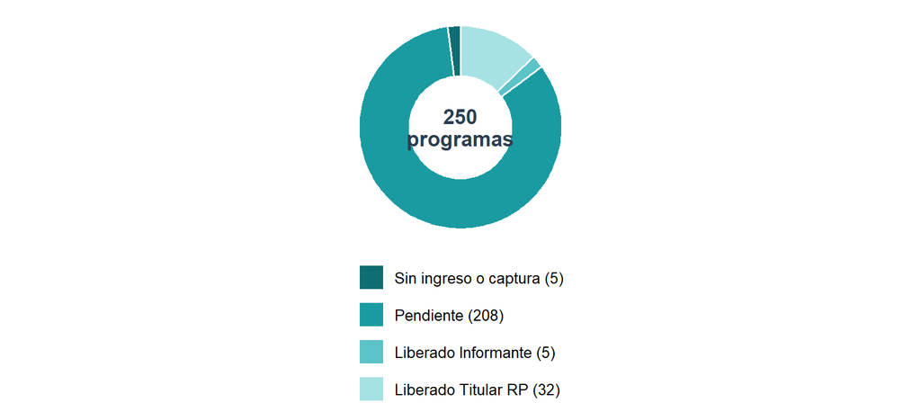

Distribución por estatus y por tipo.

```r
grafica_estatus(programas)
```

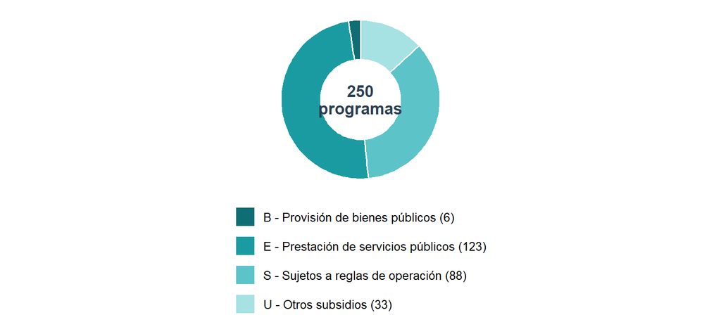

Distribución por estatus y por tipo.

```r
grafica_tipo(programas)
```

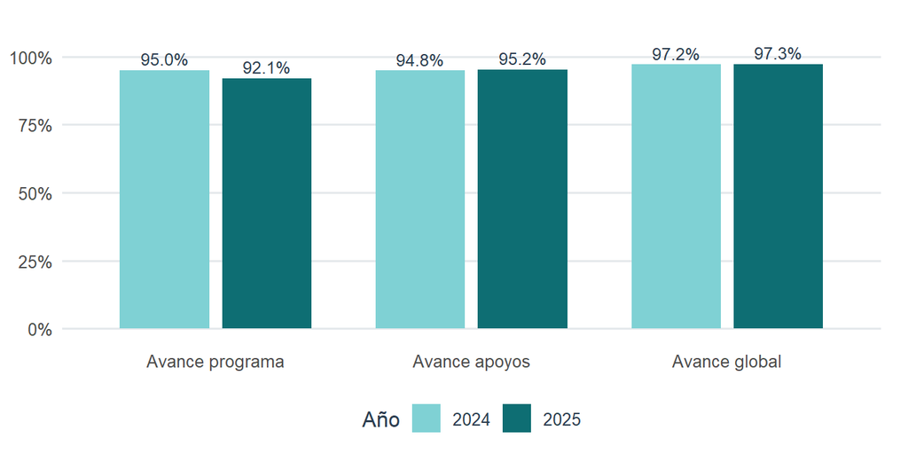

Comparativo por año.

```r
grafica_comparativo_anio(programas)
```

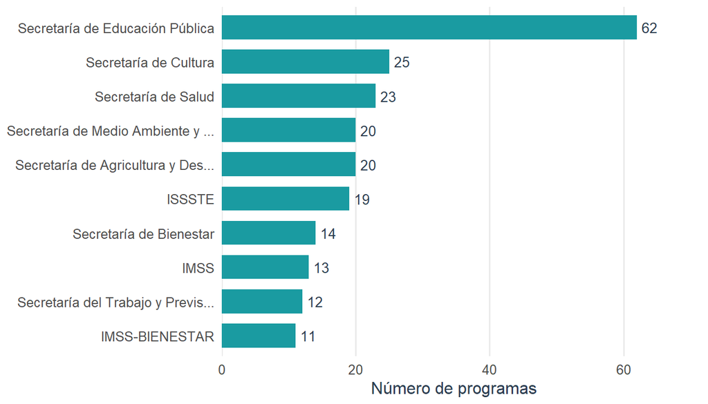

Top 10 dependencias y responsables sin asignar.

```r
grafica_top_dependencias(programas)
```

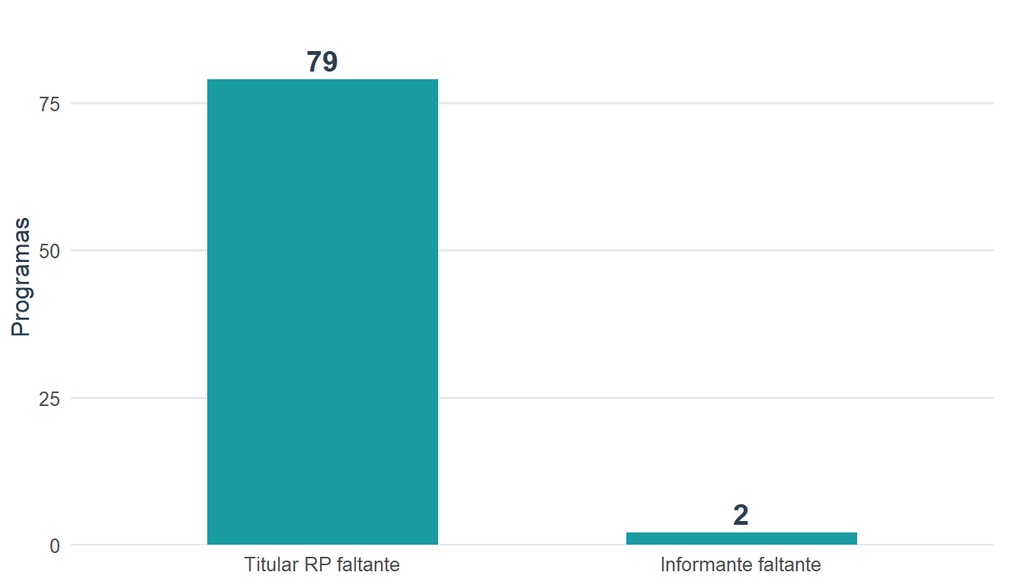

Top 10 dependencias y responsables sin asignar.

```r
grafica_responsables(programas)
```

**Ejercicio:** agrega al dashboard un KPI “Dependencias” con el número de dependencias distintas en los datos filtrados.

**Ver solución**

1. En `ui`, dentro de `div(class = "fila-kpi", ...)`, agrega: `tarjeta_kpi("kpi_dependencias", "Dependencias", "building")`
2. En `server`, agrega:

```r
output$kpi_dependencias <- renderText(
  length(unique(datos_filtrados()$DEPENDENCIA))
)
```

3. En `estilos.css`, cambia `repeat(7, ...)` por `repeat(8, ...)` en `.fila-kpi`.

**Errores comunes**

| Síntoma | Causa | Solución |
| --- | --- | --- |
| `cannot open file '../scripts/validar_datos.R'` | Se ejecutó `app.R` con `source()` | Usa `shiny::runApp("dashboard")` o el botón Run App |
| `Error in .getReactiveEnvironment()...` / `Operation not allowed without an active reactive context` | Se leyó `input$...` fuera de `reactive()` o `render*()` | Mueve ese código dentro de un contexto reactivo |
| La página no cambia al filtrar | La salida no usa `datos_filtrados()` | Revisa que cada `render*` lo llame |
| `Listening on http://127.0.0.1:...` y la consola se bloquea | Es normal: R está atendiendo al dashboard | Detenlo con `Esc` / Stop en RStudio o `Ctrl + C` en PowerShell |
| Error de puerto en uso | Otro dashboard sigue abierto | Cierra el otro o cambia `port` en `generar_dashboard.R` |

← Módulo 6 · Inicio ↑

# Referencia rápida

## Funciones usadas en el curso

| Función | Paquete | Para qué |
| --- | --- | --- |
| `c()`, `seq()`, `length()` | base | Crear y medir vectores |
| `data.frame()`, `str()`, `head()`, `summary()` | base | Crear y explorar tablas |
| `subset()`, `order()`, `aggregate()`, `table()` | base | Filtrar, ordenar y resumir |
| `is.na()`, `complete.cases()`, `na.rm = TRUE` | base | Valores faltantes |
| `as.numeric()`, `as.Date()`, `format()` | base | Convertir tipos y fechas |
| `trimws()`, `substr()`, `grepl()`, `sub()`, `paste0()` | base | Texto |
| `tryCatch()`, `stop()`, `warning()` | base | Errores |
| `excel_sheets()`, `read_excel()` | readxl | Leer Excel |
| `ggplot()`, `aes()`, `geom_col()`, `geom_histogram()`, `ggsave()` | ggplot2 | Gráficas |
| `render()` | rmarkdown | Generar documentos |
| `kable()`, `include_graphics()` | knitr | Tablas e imágenes en documentos |
| `runApp()`, `reactive()`, `render*()`, `validate()` | shiny | Dashboard |
| `page_fluid()`, `card()`, `bs_theme()` | bslib | Diseño del dashboard |

## Solución de problemas: ¿por dónde empiezo?

1. Lee el mensaje completo: **qué función** falló y **por qué**.
2. Revisa la carpeta de trabajo: `getwd()` debe terminar en `proyecto_r`.
3. Comprueba los paquetes: `source("requirements.R")`.
4. Valida los datos: `source("scripts/validar_datos.R")` o `Rscript scripts/validar_datos.R`.
5. Reinicia R (`Ctrl + Shift + F10`) y ejecuta el script desde el principio.
6. Consulta las tablas de “Errores frecuentes” de cada módulo.

## Información de la sesión